# Beaver DOC: analysis plan for the revised submission

- Show All Code
- Hide All Code
- View Source

The research questions, the variables that answer them, and the figures that go into the manuscript

Author

Leonardo Capitani

Published

September 9, 2026

**TipPurpose**

This document fixes the story of the manuscript: three research questions, the variables that answer them, and the figures that go into the main text and into Appendix S1. Everything not listed here is left out. Figure numbers in this document (Figure 1, 2, …) are its own; the manuscript figure each one becomes is written in bold above it.

# 1. The variables

The subject of every effect statement is **beaver-engineering**, the physical modification beavers create, because the upstream–downstream contrast measures the whole beaver-engineered stream. The unit of analysis is the stream.

Table 1: The derived variables used throughout this document, referenced from every figure caption below.

| Symbol | Name | Definition | Meaning (unit) | Question it answers |
| --- | --- | --- | --- | --- |
| $\text{DOC}_{up,s}$, $\text{DOC}_{down,s}$ | upstream DOC, downstream DOC | measured | DOC concentration entering / leaving the beaver-engineered stream in season $s$ ($w$ = winter, $s$ = summer) **(mg L$^{-1}$)** | What is the DOC concentration before and after the beaver-engineered stream in each season? |
| $\Delta\text{DOC}_s$ | local response | $\text{DOC}_{down,s} - \text{DOC}_{up,s}$ | the change in DOC that beaver-engineering produces in season $s$; positive = enrichment, negative = depletion **(mg L$^{-1}$)** | Does beaver-engineering increase or decrease DOC, and by how much, in each season? |
| $S$ | inherited seasonal contrast | $\text{DOC}_{up,summer} - \text{DOC}_{up,winter}$ | the winter-to-summer change of upstream DOC, i.e. what the upstream river corridor delivers to the stream **(mg L$^{-1}$)** | How much does DOC change between winter and summer in the river before it reaches the beaver-engineered stream? |
| $R_s$ | relative response | $\Delta\text{DOC}_s / \lvert S \rvert$ | how much DOC beaver-engineering adds ($R_s > 0$) or removes ($R_s < 0$) in season $s$, as a fraction of the inherited seasonal contrast **(dimensionless)** | How much does beaver-engineering add or remove DOC, relative to the inherited seasonal contrast? |
| $B$ | beaver seasonal modification | $\Delta\text{DOC}_{summer} - \Delta\text{DOC}_{winter}$ | how much beaver-engineering changes the winter-to-summer DOC contrast **(mg L$^{-1}$)** | Does beaver-engineering change the seasonal DOC contrast, beyond its effect within each season? |
| $G$ | seasonal gain | $B / S$ | $G > 0$: beaver-engineering **reinforces** the inherited seasonal contrast; $-1 < G < 0$: **dampens** it; $G < -1$: **reverses** it **(dimensionless)** | Does beaver-engineering reinforce, dampen or reverse the inherited seasonal contrast? |
| $A_\text{beaver}$, $A_\text{floodplain}$ | areas | mapped | ponded footprint of the beaver-engineered stream; contributing catchment floodplain area **(km$^2$)** | How large is the beaver-engineered footprint, and how large is the floodplain that generates $S$? |
| $F$ | footprint contrast | $A_\text{floodplain} / A_\text{beaver}$ | how much larger the floodplain area is than the beaver-engineered footprint **(dimensionless)** | How small is the beaver-engineered footprint relative to the floodplain that generates $S$? |

**Manuscript placement: Appendix S1 (Figure S10).**

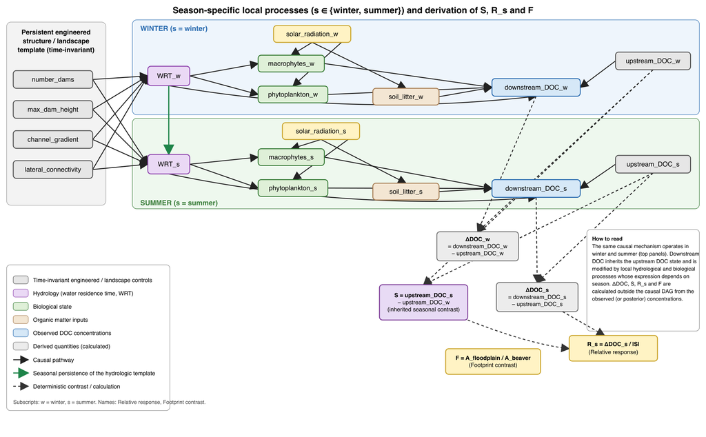

Figure 1: **Derivation of the variables.** Top: the same causal structure operates in winter and summer; downstream DOC inherits upstream DOC and is modified by local hydrological and biological processes. Bottom (dashed): $\Delta\text{DOC}_s$, $S$, $R_s$ and $F$ are calculations from the concentrations, not causal nodes. Solid arrows are causal pathways; the green arrow is the persistence of the hydrologic template between seasons. Variable definitions: Table 1.

# 2. Research questions and hypotheses

**Q1 — Direction.** *Does beaver-engineering consistently increase or decrease DOC downstream compared with upstream?* Hypothesis: if a stream is impounded by beaver dams, then the local response $\Delta\text{DOC}_s$ will not have a consistent sign across streams, because impoundment simultaneously starts DOC-producing processes — exudation and senescence of phytoplankton and macrophytes, leaching of litter and inundated soils (Aitkenhead *et al.* 1999; Sell & Overbeck 1992; Søndergaard *et al.* 1985) — and DOC-removing processes — microbial mineralization, photodegradation and sedimentation during the longer residence time (Johnston 2017; Nummi *et al.* 2018) — whose balance depends on the stream; syntheses accordingly report enrichment, no change and depletion (Grudzinski *et al.* 2022; Larsen *et al.* 2021). We further expect the balance to tilt toward enrichment in summer, when production exceeds removal (Mulholland & Hill 1997).

**Q2 — Drivers.** *Which abiotic and biotic drivers set the direction of the local response?* Hypothesis: if the number of dams increases, then water residence time increases because each dam impounds water and slows flow (Majerova *et al.* 2015; Westbrook *et al.* 2006); if water residence time and solar radiation increase, then phytoplankton and macrophyte abundance increase because nutrients are retained and light is available for photosynthesis (Feuchtmayr *et al.* 2009; Finger *et al.* 2007; Reynolds 2006); if primary producer abundance and soil litter cover increase, then $\Delta\text{DOC}_s$ increases because exudation, senescence and litter leaching release DOC (Gessner *et al.* 1999; Reitsema *et al.* 2018); if upstream DOC increases, then $\Delta\text{DOC}_s$ decreases because a larger incoming load is proportionally retained or mineralized within the pond (Larson *et al.* 2007; Wohl 2013). The thirteen path-specific hypotheses are in Appendix S1, Table S1.

**Q3 — Magnitude and seasonal modification.** *How much does beaver-engineering add or remove DOC relative to the inherited seasonal contrast, and does it reinforce, dampen or reverse that contrast?* Hypothesis, magnitude: if the season is summer, then the relative response $R_{summer}$ will be positive and a substantial fraction of the inherited seasonal contrast, because higher light and temperature raise autochthonous DOC production inside the pond independently of the upstream corridor (Battin *et al.* 2023; Mulholland & Hill 1997); if the season is winter, then $R_{winter}$ will be close to zero because primary production is minimal. Hypothesis, modification: if the summer response exceeds the winter response ($B > 0$ where $S > 0$), then the seasonal gain $G$ will be positive and beaver-engineering will reinforce the inherited seasonal contrast; because the balance of DOC-producing and DOC-removing processes is stream-specific (Q1), we expect $G$ to be heterogeneous across streams, with reinforcement, dampening and reversal all present. Because $A_\text{beaver}$ is a very small part of $A_\text{floodplain}$ (footprint contrast $F \gg 1$), both responses arise on a footprint far smaller than the corridor that generates $S$.

**Q5 — Mechanism of the sign.** *Why do some beaver-engineered streams enrich and others deplete DOC, and why does the same stream change role between seasons?* Hypothesis: if enrichment occurs where the biological and organic-matter pathways of the SCM (phytoplankton, macrophytes, litter) contribute most, and depletion where these contributions are weak and removal dominates, then decomposing the SCM’s predicted local modification into pathway contributions will separate sources from sinks, and the summer-minus-winter change of the producer contributions will track the beaver seasonal modification $B$ (Battin *et al.* 2023; Mulholland & Hill 1997). Removal processes (mineralization, photodegradation) were not measured, so whatever the measured pathways cannot explain is reported as an unresolved component, not attributed.

| Question | Answered by | This document | Manuscript |
| --- | --- | --- | --- |
| Q1 Direction | $\Delta\text{DOC}_s$ | Figure 2 | Figure 1a (main text) |
| Q2 Drivers | structural causal model | Figure 3 | Figure 1b (main text) |
| Q3 Magnitude and seasonal modification | $R_s$ (figure), $G$ (text), $F$ as context | Figure 4 | Figure 2 (main text) |
| Q4 Intensity | $R_{summer}$ and $G$ against the number of dams and the water residence time (Bayesian slope) | Figure 5 | Figure S12 (Appendix S1) |
| Spatial coherence (Discussion support) | $S$, $B$, downstream seasonal contrast $T$ | Figure 6 | Figure S11 (Appendix S1) |
| Q5 Mechanism of the sign | pathway decomposition of the SCM’s local modification | Figure 14, Figure 15 | Figure S18 (Appendix S1) |
| Model validation (Methods support) | leave-one-out and hold-out prediction of downstream DOC and $\Delta\text{DOC}$ | Figure 7 | Figure S13 (Appendix S1) |
| Methods | sampling design; $S$, $\Delta\text{DOC}_s$, $R_s$, $F$ | Figure 16 | Figure 3 (main text) |
| Derivation of the variables | — | Figure 1 | Figure S10 (Appendix S1) |

# 3. Q1 — Direction

**Manuscript placement: main text, Figure 1a (existing, unchanged).**

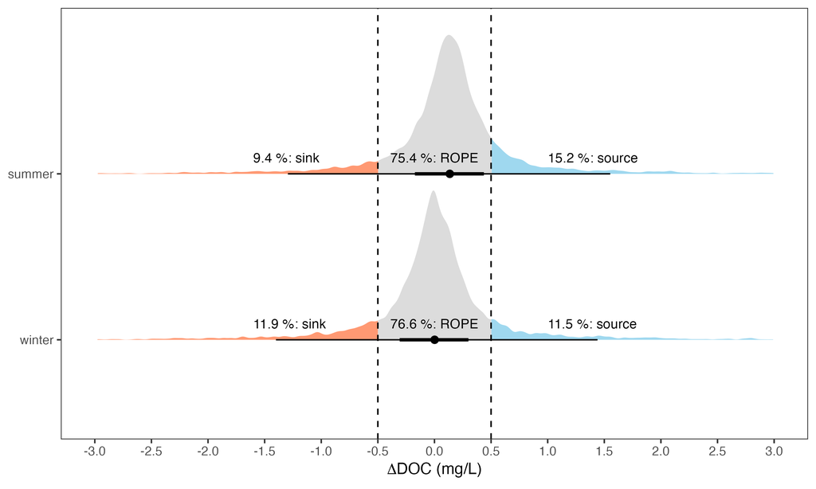

Figure 2: **Direction of the local response.** Posterior predictive distribution of $\Delta\text{DOC}_s$ for a single sampling of a beaver-engineered stream, in winter and summer, from the measurement-error model on the raw upstream and downstream concentrations. Coral: posterior predictive probability of a sink response ($\Delta\text{DOC}_s < -0.5$ mg L$^{-1}$); grey: negligible response (ROPE $\pm 0.5$ mg L$^{-1}$); skyblue: source response ($\Delta\text{DOC}_s > 0.5$ mg L$^{-1}$). Point: median; bars: 66% and 95% intervals. $\Delta\text{DOC}_s$ is defined in Table 1.

```r
# raw data: one row per sampling; pair each stream's winter and summer sampling
m <- read.csv(here("data", "processed", "m12.csv"))
w <- m |> filter(season == "winter") |> select(site, beaver_territory, up_w = DOC_input, dn_w = DOC_out,
                                                 Afp = A_floodplain_km2, Abv = A_beaver_km2)
s <- m |> filter(season == "summer") |> select(site, beaver_territory, up_s = DOC_input, dn_s = DOC_out)
# the 158 streams with both seasons complete; local responses and footprint contrast
d <- inner_join(w, s, by = c("site", "beaver_territory")) |> filter(complete.cases(up_w, dn_w, up_s, dn_s)) |>
  mutate(dw = dn_w - up_w,      # local response in winter
         ds = dn_s - up_s,      # local response in summer
         F  = Afp / Abv)        # footprint contrast
# shares of enrichment by season, and streams that switch direction between seasons
sw <- d |> summarise(n = n(), winter_enrich = mean(dw > 0), summer_enrich = mean(ds > 0),
                     dep_to_enr = sum(dw < 0 & ds > 0), enr_to_dep = sum(dw > 0 & ds < 0))
```

# 4. Q2 — Drivers

**Manuscript placement: main text, Figure 1b (redrawn: the outcome is downstream DOC).**

The chunk below draws the structural causal model as it will appear in the manuscript. The layout is fixed by hand (node positions and edge routing); the numbers are the posterior mean effects of model `b1_downstream`, and each edge’s line type encodes the posterior probability of its direction.

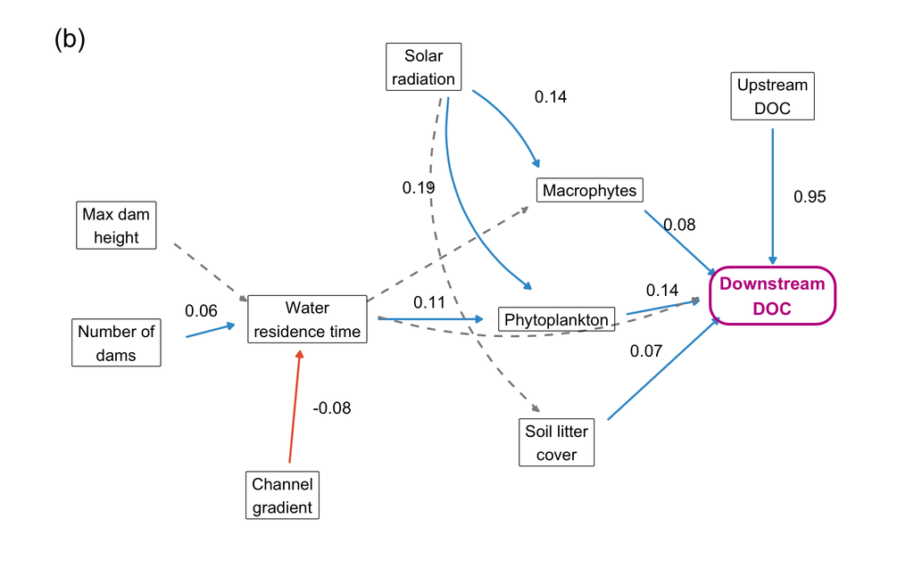

Figure 3: **Drivers of downstream DOC.** Structural causal model with downstream DOC as the outcome (model `b1_downstream`) and the posterior mean standardized effects; the upstream-DOC path is the inheritance slope (0.95, mg per mg). Skyblue: positive and coral: negative effects with posterior probability above 0.90; dashed grey: no-evidence.

```r
# ---- node positions (x, y on a 0-10 canvas) --------------------------------
nodes <- data.frame(
  name = c("Max dam\nheight", "Number of\ndams", "Channel\ngradient", "Water\nresidence time",
           "Solar\nradiation", "Macrophytes", "Phytoplankton", "Soil litter\ncover",
           "Upstream\nDOC", "Downstream\nDOC"),
  x = c(0.9, 0.9, 2.9, 3.2, 4.6, 6.6, 6.2, 6.2, 8.8, 8.8),
  y = c(6.6, 4.6, 2.0, 5.0, 9.3, 7.2, 5.0, 2.9, 8.8, 5.4))
rownames(nodes) <- c("dh", "nd", "gr", "wrt", "sol", "mac", "pla", "lit", "up", "out")
# ---- edges: posterior mean effect (label), class by P > 0.90, curvature ----
edges <- read.csv(text = 'from,to,label,class,curv,lx,ly
dh,wrt,,none,0,0,0
nd,wrt,0.06,pos,0,-0.1,0.35
gr,wrt,-0.08,neg,0,0.45,0
wrt,pla,0.11,pos,0,0,0.30
wrt,mac,,none,0,0,0
wrt,out,,none,0.18,0,0
sol,mac,0.14,pos,-0.15,0.55,0.55
sol,pla,0.19,pos,0.30,-0.85,0.10
sol,lit,,none,0.30,0,0
mac,out,0.08,pos,0,0,0.32
pla,out,0.14,pos,0,0,0.30
lit,out,0.07,pos,0,-0.2,0.32
up,out,0.95,pos,0,0.45,0')
# shorten each arrow so it starts/ends at the box border, not the centre
a <- merge(edges, nodes, by.x = "from", by.y = "row.names")
a <- merge(a, nodes, by.x = "to", by.y = "row.names", suffixes = c("", "2"))
dx <- a$x2 - a$x; dy <- a$y2 - a$y; L <- sqrt(dx^2 + dy^2)
a$x0 <- a$x + dx / L * 0.85; a$y0 <- a$y + dy / L * 0.55
a$x1 <- a$x2 - dx / L * 0.90; a$y1 <- a$y2 - dy / L * 0.55
a$xm <- (a$x0 + a$x1) / 2 + a$lx; a$ym <- (a$y0 + a$y1) / 2 + a$ly
pal2 <- c(pos = "#3B9AD1", neg = "#E8603C", none = "grey55")   # skyblue / coral / grey
lty2 <- c(pos = "solid",   neg = "solid",   none = "dashed")
arr <- arrow(length = unit(0.16, "cm"), type = "closed")
pq2 <- ggplot()
st <- subset(a, curv == 0)   # straight and curved arrows drawn separately
pq2 <- pq2 + geom_segment(data = st, aes(x = x0, y = y0, xend = x1, yend = y1),
                          colour = pal2[st$class], linetype = lty2[st$class], linewidth = 0.7, arrow = arr)
for (i in which(a$curv != 0))
  pq2 <- pq2 + geom_curve(data = a[i, ], aes(x = x0, y = y0, xend = x1, yend = y1),
                          curvature = a$curv[i], colour = pal2[a$class[i]],
                          linetype = lty2[a$class[i]], linewidth = 0.7, arrow = arr)
pq2 <- pq2 +
  geom_text(data = subset(a, label != ""), aes(x = xm, y = ym, label = label), size = 4.2) +
  geom_label(data = nodes[rownames(nodes) != "out", ], aes(x = x, y = y, label = name),
             size = 4.1, label.padding = unit(0.3, "lines"), label.r = unit(0.05, "lines")) +
  geom_label(data = nodes["out", ], aes(x = x, y = y, label = name), size = 4.4,
             fontface = "bold", label.padding = unit(0.45, "lines"),
             label.r = unit(0.9, "lines"), linewidth = 0.9, colour = "#C0208E") +
  annotate("text", x = 0.15, y = 9.8, label = "(b)", size = 6.5, hjust = 0) +
  xlim(0, 10) + ylim(1.2, 10) + theme_void()
ggsave(here("images", "Figure_1b_downstream.png"), pq2, width = 9, height = 5.6, dpi = 300, bg = "white")
pq2
```

**NoteKey message of Figure 3**

- **Inheritance dominates.** Downstream DOC carries 0.95 [0.92, 0.98] mg per mg of upstream DOC — by far the largest path.
- **Local modification through biology.** Phytoplankton +0.14, macrophytes +0.08, soil litter +0.07 (standardized effects on downstream DOC); solar radiation feeds the producers (+0.19, +0.14).
- **The dams act only indirectly and weakly.** Number of dams +0.06 and channel gradient −0.08 on water residence time; residence time +0.11 on phytoplankton; no direct residence-time → DOC path.
- **Implication.** A beaver-engineered stream inherits its DOC and then adds to it; the addition is decided by light and primary producers, not by the size of the engineering. The producer effects are prior-informed (16 summer streams; section 9) and should be presented as such.

**Parameterization.** The structural causal model is reported with **downstream DOC as the outcome**: upstream DOC enters as the inherited incoming state with a freely estimated inheritance slope, and $\Delta\text{DOC}_s$ is computed from the posterior afterwards as $\text{DOC}_{down,s} - \text{DOC}_{up,s}$, so upstream DOC is never both a predictor and part of the outcome. This reading replaces the older wording of Q2, which described the upstream-DOC path as upstream DOC *causing greater retention*; downstream DOC instead **inherits** the upstream state (slope 0.95 mg per mg), and the hydrological/biological pathways are local modifications around that inherited background, not retention of it. This model (`b1_downstream`, `notebook/scm_rebuild.qmd`) is the $\Delta$DOC model in a different parameterization: every mediator effect agrees to the second decimal, and the upstream-DOC path is re-read as an inheritance slope of **0.95 [0.92, 0.98]** — downstream DOC inherits 95% of the upstream concentration, mg per mg. Figure 1b is redrawn accordingly (Figure 3); the Methods gain one sentence stating the parameterization and the inheritance slope.

**Robustness check: does fixing the inheritance slope at 1 change anything else?** `b1_downstream` estimates the slope freely (prior Normal(1, 0.3), posterior 0.95). A second fit, `b1_downstream_fixed` (`notebook/scm_downstream_fixed_fit.R`), pins it at 1 (prior Normal(1, 0.001), the standard way to fix an `mi()` coefficient in brms) and is otherwise identical.

Posterior mean [95% CrI]. Fixing the inheritance slope at 1 is a robustness check, not a preferred model.

| Parameter | Free slope (b1_downstream) | Fixed at 1 (b1_downstream_fixed) |
| --- | --- | --- |
| Inheritance slope | 0.945 [0.914, 0.977] | 1.000 [0.998, 1.002] |
| Macrophytes | 0.079 [-0.005, 0.169] | 0.072 [-0.010, 0.160] |
| Phytoplankton | 0.141 [0.032, 0.252] | 0.130 [0.023, 0.241] |
| Soil litter cover | 0.068 [-0.031, 0.174] | 0.071 [-0.028, 0.178] |
| Water residence time | 0.030 [-0.059, 0.118] | 0.047 [-0.038, 0.131] |
| Intercept | 0.152 [0.015, 0.287] | 0.023 [-0.092, 0.132] |

# 5. Q3 — Magnitude and seasonal modification: $R_s$ and $G$

The analysis uses the **158 streams with both a winter and a summer sampling**.

$R_s$, $B$ and $G$ are computed from posterior draws of each stream’s concentrations (Bayesian measurement-error model, `notebook/concentrations_fit.qmd`; the model belongs in the Methods), so no derived quantity is ever formed from raw values and the uncertainty is carried through (4000 posterior draws per stream).

```r
# LR holds one matrix per quantity: rows = 4000 posterior draws, columns = 158 streams
LR <- readRDS(here("results", "concentrations_thin.rds"))
R_s <- LR$R_s   # relative response in summer, per draw and stream
R_w <- LR$R_w   # relative response in winter
S_m <- LR$S     # inherited seasonal contrast
# medR: for each posterior draw, the median across streams -> a posterior
# distribution of the across-stream median (optionally on a subset of streams)
medR <- function(R, keep = rep(TRUE, ncol(R))) apply(R[, keep, drop = FALSE], 1, median)
# per-stream median |S|, used only for the small-denominator stability check
absS <- apply(abs(S_m), 2, median)
# qf: format a posterior as "median [95% credible interval]"
qf   <- function(x) sprintf("%.2f [%.2f, %.2f]", median(x), quantile(x, .025), quantile(x, .975))
q3 <- tibble(
  Quantity = c("Median $R_{summer}$ across streams", "Median $R_{winter}$ across streams", "$R_{summer} - R_{winter}$",
               "Median $R_{summer}$, excluding the 20% smallest $\\lvert S \\rvert$ (ratio-stability check)"),
  `Posterior median [95% CrI]` = c(qf(medR(R_s)), qf(medR(R_w)), qf(medR(R_s) - medR(R_w)), qf(medR(R_s, absS > quantile(absS, .2)))),
  `P(> 0)` = sprintf("%.3f", c(mean(medR(R_s) > 0), mean(medR(R_w) > 0), mean(medR(R_s) - medR(R_w) > 0),
                               mean(medR(R_s, absS > quantile(absS, .2)) > 0))))
kable(q3)
```

| Quantity | Posterior median [95% CrI] | P(> 0) |
| --- | --- | --- |
| Median $R_{summer}$ across streams | 0.21 [0.11, 0.33] | 1.000 |
| Median $R_{winter}$ across streams | 0.00 [-0.05, 0.06] | 0.550 |
| $R_{summer} - R_{winter}$ | 0.21 [0.09, 0.34] | 1.000 |
| Median $R_{summer}$, excluding the 20% smallest $\lvert S \rvert$ (ratio-stability check) | 0.12 [0.04, 0.22] | 0.998 |

```r
# streams whose summer relative response is positive (or negative) with P > 0.90
n_add <- sum(colMeans(R_s > 0) > 0.90); n_rem <- sum(colMeans(R_s < 0) > 0.90); n_str <- ncol(R_s)
# Seasonal gain G = B / S, per stream, from the same posterior draws
# beaver seasonal modification B = summer response - winter response, per draw
B_m <- LR$ds - LR$dw
# seasonal gain G = B / S: does beaver-engineering reinforce (G > 0),
# dampen (-1 < G < 0) or reverse (G < -1) the inherited seasonal contrast?
G_m <- B_m / S_m
g_med <- median(apply(G_m, 1, function(g) median(g)))  # posterior median of the across-stream median gain
```

**Manuscript placement: main text, Figure 2 (new; replaces the amplification-factor figure).**

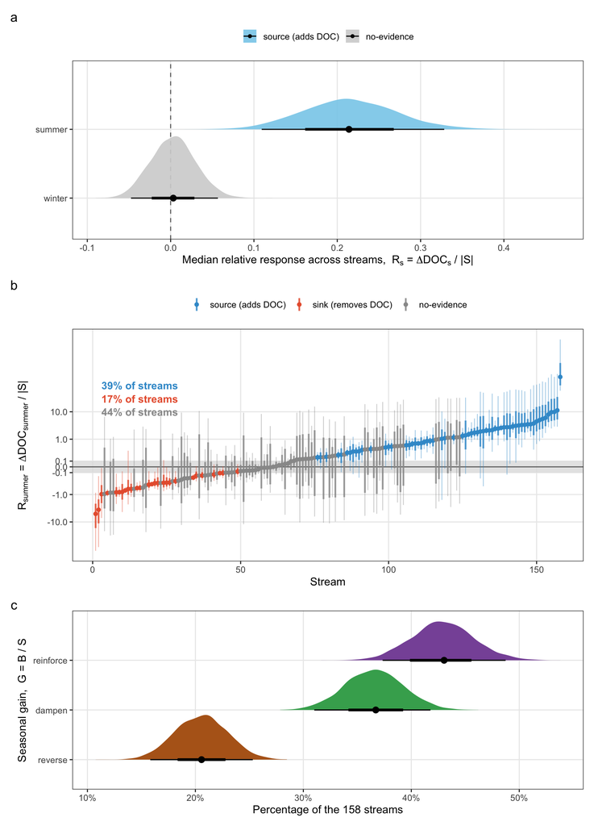

Figure 4: **Relative response $R_s$ and seasonal gain $G$ of beaver-engineering.** (a) Posterior distribution of the median relative response across the 158 streams, in winter and summer; point: posterior median, bars: 66% and 95% credible intervals; dashed line: no response. (b) Relative response of each stream in summer: posterior median with 66% (thick) and 95% (thin) credible intervals, streams ranked by their median; the grey band marks $\lvert R_{summer} \rvert < 0.1$. The vertical axis is linear between $-0.1$ and $0.1$ and logarithmic beyond, so small and large responses are both readable. In panels (a) and (b) skyblue: source (beaver-engineering adds DOC, P > 0.90), coral: sink (removes DOC, P > 0.90), grey: no-evidence — the same colours as in the direction figure; panel (b) prints the percentage of the 158 streams in each colour directly on the plot. (c) Out of the 158 streams, what percentage reinforce ($G > 0$, make the inherited seasonal contrast bigger), dampen ($-1 < G < 0$, make it smaller) or reverse ($G < -1$, flip its sign)? Each stream is classified on every posterior draw, so each bar is a full posterior distribution of that percentage, with its own uncertainty — not a single count of streams sorted into fixed bins; point: posterior median percentage, bars: 66% and 95% credible intervals. $R_s$, $G$, $B$ and $S$ are defined in Table 1.

```r
# classify by posterior probability: add if P(R > 0) > 0.90, remove if P(R < 0) > 0.90, else no-evidence
cls <- function(p_add) case_when(p_add > 0.90 ~ "add", p_add < 0.10 ~ "remove", TRUE ~ "none")
lab <- c(add = "source (adds DOC)", remove = "sink (removes DOC)", none = "no-evidence")   # P > 0.90 stated once, in the caption

# ---- panel (a): across-stream median, winter and summer --------------------
pop <- bind_rows(tibble(season = "summer", v = medR(R_s)), tibble(season = "winter", v = medR(R_w))) |>
  mutate(season = factor(season, levels = c("winter", "summer"))) |>
  group_by(season) |> mutate(class = cls(mean(v > 0))) |> ungroup()
pa <- ggplot(pop, aes(x = v, y = season, fill = class)) +
  geom_vline(xintercept = 0, linetype = "dashed", colour = "grey45") +
  stat_halfeye(.width = c(.66, .95), point_interval = "median_qi", alpha = .9) +  # 66% and 95% intervals
  scale_fill_manual(values = PAL, labels = lab, breaks = names(lab), name = NULL, drop = FALSE) +
  labs(x = expression("Median relative response across streams,  "*R[s]*" = "*Delta*DOC[s]*" / |S|"), y = NULL) +
  theme_bw(base_size = 12) + theme(panel.grid.minor = element_blank(), legend.position = "top")

# ---- panel (b): each stream's summer relative response, ranked -------------
# per stream: posterior median, 66% and 95% credible intervals, and its class
per <- tibble(med  = apply(R_s, 2, median),
              lo95 = apply(R_s, 2, quantile, .025), hi95 = apply(R_s, 2, quantile, .975),
              lo66 = apply(R_s, 2, quantile, .17),  hi66 = apply(R_s, 2, quantile, .83),
              class = cls(colMeans(R_s > 0))) |> arrange(med) |> mutate(rank = row_number())
# percentage of the 158 streams in each colour: the legend names the colour,
# the in-panel text gives its share (top-left corner is empty of points)
pct_b <- prop.table(table(factor(per$class, levels = c("add", "remove", "none")))) * 100
pct_lab <- tibble(class = c("add", "remove", "none"),
                   txt = sprintf("%.0f%% of streams", pct_b[c("add", "remove", "none")]),
                   y = c(90, 30, 10))   # stacked top to bottom on the log axis
# axis transform: linear inside [-0.1, 0.1], logarithmic beyond
psl <- pseudo_log_trans(sigma = 0.1, base = 10)
pb <- ggplot(per, aes(x = rank, y = med, colour = class)) +
  annotate("rect", xmin = -Inf, xmax = Inf, ymin = -0.1, ymax = 0.1, fill = "grey88", alpha = .8) +
  geom_hline(yintercept = 0, colour = "grey45") +
  geom_linerange(aes(ymin = lo95, ymax = hi95), alpha = .45, linewidth = 0.4) +  # 95% interval (thin)
  geom_linerange(aes(ymin = lo66, ymax = hi66), alpha = .8, linewidth = 0.9) +   # 66% interval (thick)
  geom_point(size = 1.6) +
  geom_text(data = pct_lab, aes(x = 3, y = y, label = txt, colour = class), hjust = 0, size = 4, fontface = "bold", show.legend = FALSE) +
  scale_colour_manual(values = c(add = "#3B9AD1", remove = "#E8603C", none = "grey60"), labels = lab, breaks = names(lab), name = NULL) +
  scale_y_continuous(trans = psl, breaks = c(-10, -1, -0.1, 0, 0.1, 1, 10)) +
  labs(x = "Stream", y = expression(R[summer]*" = "*Delta*DOC[summer]*" / |S|")) +
  theme_bw(base_size = 12) + theme(panel.grid.minor = element_blank(), legend.position = "top")
# ---- panel (c): posterior share of streams that reinforce/dampen/reverse ---
# classify every stream on EVERY posterior draw (no P > 0.90 threshold), then
# compute the proportion in each zone per draw -- this gives a posterior
# distribution of the proportion itself, propagating its own uncertainty,
# rather than a single count built from per-stream point classifications.
zone <- function(g) case_when(g > 0 ~ "reinforce", g > -1 ~ "dampen", TRUE ~ "reverse")
zmat <- apply(G_m, c(1, 2), zone)                       # same shape as G_m, one label per draw x stream
gprop <- as_tibble(t(apply(zmat, 1, function(row)        # proportion per zone, one row per draw
  c(reinforce = mean(row == "reinforce"), dampen = mean(row == "dampen"), reverse = mean(row == "reverse"))))) |>
  pivot_longer(everything(), names_to = "zone", values_to = "p") |>
  mutate(zone = factor(zone, levels = c("reverse", "dampen", "reinforce")))
gpal <- c(reinforce = "#8856A7", dampen = "#41AB5D", reverse = "#B5651D")   # light brown
pc <- ggplot(gprop, aes(x = p, y = zone, fill = zone)) +
  stat_halfeye(.width = c(.66, .95), point_interval = "median_qi") +   # 66% and 95% credible intervals
  scale_fill_manual(values = gpal, guide = "none") +
  scale_x_continuous(labels = label_percent(accuracy = 1)) +
  labs(x = "Percentage of the 158 streams", y = expression("Seasonal gain,  "*G*" = "*B*" / "*S)) +
  theme_bw(base_size = 12) + theme(panel.grid.minor = element_blank())
fig2 <- pa / pb / pc + plot_layout(heights = c(1, 1.3, 1)) + plot_annotation(tag_levels = "a")
ggsave(here("results", "figures", "plan", "fig_R.png"), fig2, width = 9, height = 11, dpi = 300)
fig2
# summary of panel (c) for the key message, one row per zone
gsum <- gprop |> group_by(zone) |> summarise(med = median(p), lo = quantile(p, .025), hi = quantile(p, .975))
gz <- function(z) gsum |> filter(zone == z)

# same +/-0.1 ROPE as panel (b)'s grey band, applied to R_summer, to compare
# against @fig-q1's ROPE logic (see the note below)
zone_r <- function(r) case_when(r > 0.1 ~ "source", r < -0.1 ~ "sink", TRUE ~ "negligible")
rzmat <- apply(R_s, c(1, 2), zone_r)
rprop <- as_tibble(t(apply(rzmat, 1, function(row)
  c(source = mean(row == "source"), negligible = mean(row == "negligible"), sink = mean(row == "sink"))))) |>
  pivot_longer(everything(), names_to = "zone", values_to = "p")
rz <- function(z) rprop |> filter(zone == z) |> summarise(med = median(p))
```

**ImportantKey message of Figure 4**

- **(a) Magnitude.** Winter: relative response 0.00 — nothing added. Summer: beaver-engineering adds DOC equal to 21% of the inherited seasonal contrast $S$ (95% CrI 11–33%).
- **(b) Heterogeneity.** In summer 39% of streams (62 of 158) are DOC sources, 17% (27) are sinks, the rest no-evidence.
- **(c) Seasonal gain.** 43% (37–49%) of streams reinforce the inherited seasonal contrast, 37% dampen it, 21% reverse it; median gain -0.13.
- **Implication.** Beaver-engineering adds about one fifth of the seasonal DOC signal in summer and nothing in winter, and it does not shift the seasonal contrast in one direction — it redistributes it stream by stream. Ecologically, beaver ponds are seasonal control points on a regionally inherited signal, not amplifiers of it.

**NoteHow Figure 2 and Figure 4 fit together**

Figure 2 and Figure 4 are not two conflicting results — they answer two different questions, so one naturally reads as “mostly nothing detectable” and the other as “most streams have a clear sign.”

- **Figure 2 asks: if someone visits a stream and takes one water sample, what would they most likely find?** This is a single field visit — the way almost every published beaver–DOC study, including the ones this manuscript is compared against, actually samples. The answer: mostly nothing an ecologist would call a real change.
- **Figure 4 asks: what is each stream’s true relative response, according to the best estimate the model can produce from everything it knows?** This is the paper’s actual result — it does not simulate a single field visit, it reports the model’s estimate of the real value. The answer: most streams have a clear sign.

Methods sentence: state once that Figure 1a reports the posterior *predictive* distribution of a single new sampling (so it includes the instrument error), while $R_s$, $B$ and $G$ are computed from each stream’s posterior *parameter* estimate (the model’s estimate of the true concentration).

# 6. Q4 — Intensity of beaver-engineering and the response

**Question:** Is the local response ordered by the intensity of beaver-engineering — the number of dams and the water residence time — or by something else?

**Manuscript placement: Appendix S1 (Figure S12), with one sentence in the Results.**

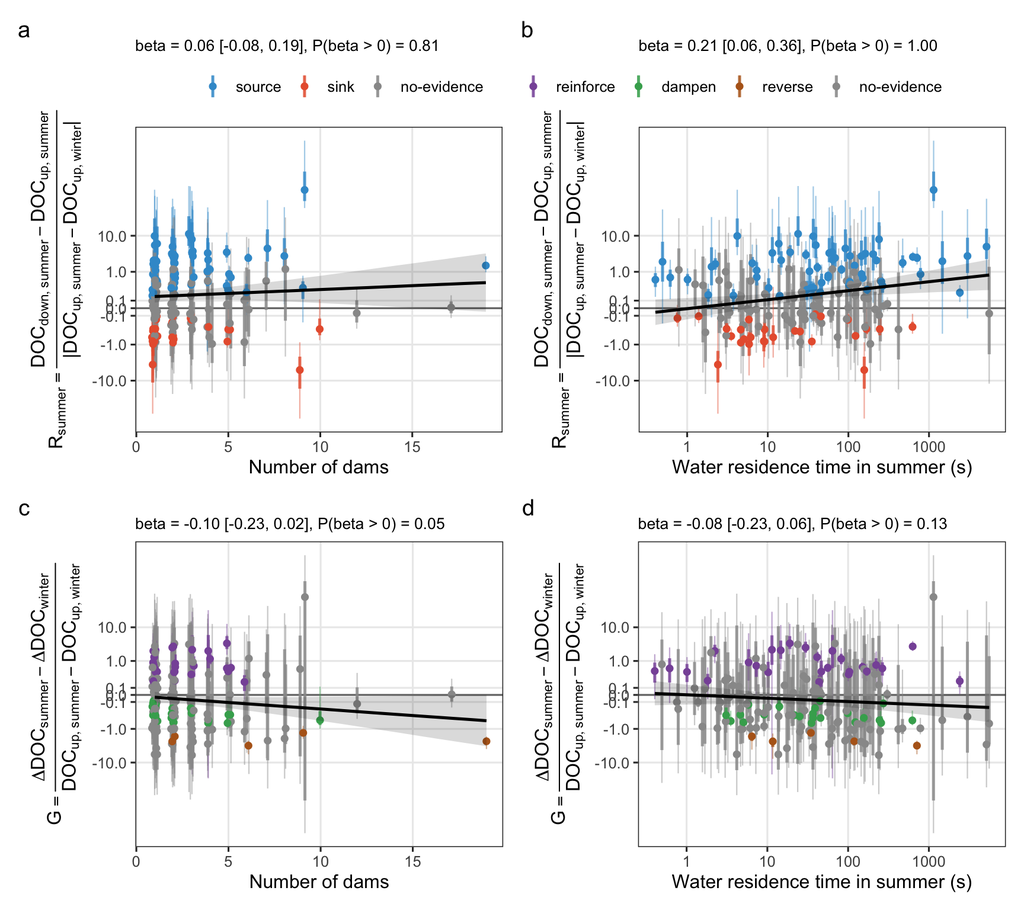

```r
library(brms)
# covariates per analysed stream: number of dams and summer water residence time (from m6)
cov <- read.csv(here("data", "processed", "m6.csv")) |> filter(season == "summer") |>
  select(site, beaver_territory, n_dams, wrt = water_res_time)
cv <- LR$d |> select(site, beaver_territory) |> left_join(cov, by = c("site", "beaver_territory"))
# per-stream classes for colouring (same rules as Figure 2)
r_class <- cls(colMeans(R_s > 0))
g_class <- apply(G_m, 2, function(g) {
  p <- c(reinforce = mean(g > 0), dampen = mean(g > -1 & g < 0), reverse = mean(g < -1))
  if (max(p) > 0.90) names(p)[which.max(p)] else "no-evidence" })
# the pseudo-log transform used on the figure axis (scales::pseudo_log_trans, sigma = 0.1)
plog <- function(x) asinh(x / 0.2) / log(10)
# Bayesian ordering: Student-t regression of the transformed response on the standardized
# gradient, each stream weighted by its own posterior uncertainty (known se)
slope_fit <- function(M, x, tag) {
  ok <- !is.na(x); TM <- plog(M[, ok])
  dd <- tibble(y = apply(TM, 2, median), se_y = apply(TM, 2, sd), x = as.numeric(scale(x[ok])))
  brm(bf(y | se(se_y, sigma = TRUE) ~ 1 + x), data = dd, family = student(),
      prior = c(prior(normal(0, 1), class = "b"), prior(normal(0, 2), class = "Intercept"),
                prior(student_t(3, 0, 1), class = "sigma"), prior(gamma(2, 0.1), class = "nu")),
      chains = 4, iter = 3000, warmup = 1000, seed = 7, backend = "cmdstanr", refresh = 0,
      file = here("results", "models_fit", paste0("intensity_", tag)))
}
fits <- list(R_dams = slope_fit(R_s, cv$n_dams, "R_dams"), R_wrt = slope_fit(R_s, log10(cv$wrt), "R_wrt"),
             G_dams = slope_fit(G_m, cv$n_dams, "G_dams"), G_wrt = slope_fit(G_m, log10(cv$wrt), "G_wrt"))
beta <- lapply(fits, function(f) as_draws_df(f)$b_x)
b_lab <- function(b) sprintf("beta = %.2f [%.2f, %.2f], P(beta > 0) = %.2f", median(b), quantile(b, .025), quantile(b, .975), mean(b > 0))
qs <- function(M) tibble(med = apply(M, 2, median), lo95 = apply(M, 2, quantile, .025), hi95 = apply(M, 2, quantile, .975),
                         lo66 = apply(M, 2, quantile, .17), hi66 = apply(M, 2, quantile, .83))
rpal <- c(add = "#3B9AD1", remove = "#E8603C", none = "grey60")
rlab <- c(add = "source", remove = "sink", none = "no-evidence")
gpal2 <- c(reinforce = "#8856A7", dampen = "#41AB5D", reverse = "#B5651D", `no-evidence` = "grey60")
inv_plog <- function(y) 0.2 * sinh(y * log(10))   # back from the pseudo-log scale
# posterior regression line of the slope model, drawn on the original scale of the response
fit_line <- function(fit, x_raw, logx) {
  ok <- !is.na(x_raw); xr <- if (logx) log10(x_raw[ok]) else x_raw[ok]
  grid <- seq(min(xr), max(xr), length.out = 60)
  nd <- tibble(x = (grid - mean(xr)) / sd(xr), se_y = 0)
  ep <- posterior_epred(fit, newdata = nd)                  # draws x grid, pseudo-log scale
  tibble(x = if (logx) 10^grid else grid, med = inv_plog(apply(ep, 2, median)),
         lo = inv_plog(apply(ep, 2, quantile, .025)), hi = inv_plog(apply(ep, 2, quantile, .975)))
}
panel <- function(M, x, xlab, class, pal, labs_, ylab, sub, fit, logx = FALSE) {
  d <- qs(M) |> mutate(x = x, class = factor(class, levels = names(pal)))
  pos <- if (logx) "identity" else position_jitter(width = .15, height = 0, seed = 1)
  ln <- fit_line(fit, x, logx)
  p <- ggplot(d, aes(x = x, y = med)) +
    geom_hline(yintercept = 0, colour = "grey45") +
    geom_linerange(aes(ymin = lo95, ymax = hi95, colour = class), alpha = .45, linewidth = 0.4, position = pos) +
    geom_linerange(aes(ymin = lo66, ymax = hi66, colour = class), alpha = .8, linewidth = 0.9, position = pos) +
    geom_point(aes(colour = class), size = 1.6, position = pos) +
    geom_ribbon(data = ln, aes(x = x, ymin = lo, ymax = hi), inherit.aes = FALSE, fill = "black", alpha = .15) +
    geom_line(data = ln, aes(x = x, y = med), inherit.aes = FALSE, colour = "black", linewidth = 0.9) +
    scale_colour_manual(values = pal, labels = labs_, breaks = names(pal), name = NULL) +
    scale_y_continuous(trans = psl, breaks = c(-10, -1, -0.1, 0, 0.1, 1, 10)) +
    labs(x = xlab, y = ylab, subtitle = sub) + theme_bw(base_size = 12) +
    theme(panel.grid.minor = element_blank(), legend.position = "top", plot.subtitle = element_text(size = 10))
  if (logx) p + scale_x_log10() else p
}
ylab_R <- expression(R[summer] == frac(DOC[list(down, summer)] - DOC[list(up, summer)], "|" * DOC[list(up, summer)] - DOC[list(up, winter)] * "|"))
ylab_G <- expression(G == frac(Delta * DOC[summer] - Delta * DOC[winter], DOC[list(up, summer)] - DOC[list(up, winter)]))
p1 <- panel(R_s, cv$n_dams, "Number of dams", r_class, rpal, rlab, ylab_R, b_lab(beta$R_dams), fits$R_dams)
p2 <- panel(R_s, cv$wrt, "Water residence time in summer (s)", r_class, rpal, rlab, ylab_R, b_lab(beta$R_wrt), fits$R_wrt, logx = TRUE)
p3 <- panel(G_m, cv$n_dams, "Number of dams", g_class, gpal2, names(gpal2), ylab_G, b_lab(beta$G_dams), fits$G_dams)
p4 <- panel(G_m, cv$wrt, "Water residence time in summer (s)", g_class, gpal2, names(gpal2), ylab_G, b_lab(beta$G_wrt), fits$G_wrt, logx = TRUE)
figI <- (p1 + p2) / (p3 + p4) + plot_layout(guides = "collect") + plot_annotation(tag_levels = "a") &
  theme(legend.position = "top")
ggsave(here("results", "figures", "plan", "fig_intensity.png"), figI, width = 10, height = 8, dpi = 300)
figI
bt <- function(k) sprintf("%.2f [%.2f, %.2f]", median(beta[[k]]), quantile(beta[[k]], .025), quantile(beta[[k]], .975))
bp <- function(k) sprintf("%.2f", mean(beta[[k]] > 0))
```

**NoteKey message of Figure 5**

- **Water residence time orders the summer response, weakly.** $\beta$ = 0.21 [0.06, 0.36] per SD of log residence time, $P(\beta > 0)$ = 1.00.
- **The number of dams does not.** $\beta$ = 0.06 [-0.08, 0.19], $P(\beta > 0)$ = 0.81.
- **The seasonal gain is ordered by neither.** -0.10 [-0.23, 0.02] (dams) and -0.08 [-0.23, 0.06] (residence time).
- **Implication.** Longer impoundment favours DOC release in summer (the stream-level counterpart of the Q2 path residence time → phytoplankton → DOC), but sources, sinks, reinforcing and dampening streams occur at every level of engineering: the intensity of beaver-engineering sets the stage, it does not decide the sign. Sentence for Appendix S1 (Figure S12) as above.

# 7. Spatial coherence of the seasonal contrasts

**Question** (Discussion support)**:** *the inherited seasonal contrast is generated over whole floodplains — is the modification that beaver-engineering imposes on it organised at the same regional scale, or is it stream-specific?* The answer decides how the Discussion frames beaver-engineering: if $B$ were regionally coherent, beaver-engineered streams would act together as a landscape-scale control on the seasonal DOC signal; if $B$ is spatially incoherent, each beaver-engineered stream is an independent local control point on a regional signal — the framing the manuscript title claims.

For each stream we correlate its value with the mean of its 8 nearest neighbours (Spearman), computed on every posterior draw of the concentrations, so the coherence estimate carries the full uncertainty. $T = \text{DOC}_{down,summer} - \text{DOC}_{down,winter}$ is the **downstream seasonal contrast** ($T = S + B$).

**Manuscript placement: Appendix S1 (Figure S11), plus one sentence in the Discussion.**

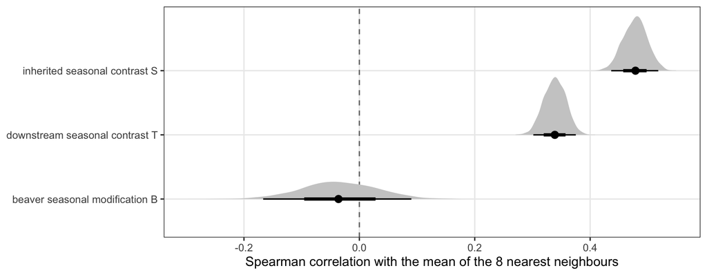

Figure 6: **Spatial coherence of the inherited seasonal contrast $S$, the beaver seasonal modification $B$ and the downstream seasonal contrast $T$.** Posterior distribution of the Spearman correlation between each stream’s value and the mean of its 8 nearest neighbours, computed on every posterior draw of the concentrations. Point: median; bars: 66% and 95% credible intervals; dashed line: no spatial coherence. $S$ and $B$ are defined in Table 1 ($T = S + B$).

```r
# stream coordinates (longitude, latitude of the upstream sampling point)
co <- read.csv(here("data", "processed", "m6.csv")) |> distinct(site, .keep_all = TRUE) |>
  select(site, lon = x_upstream, lat = y_upstream)
d2 <- left_join(LR$d, co, by = "site")
# planar distances in km (adequate at the scale of Switzerland)
kmx <- (d2$lon - mean(d2$lon)) * 111.32 * cos(mean(d2$lat) * pi / 180)
kmy <- (d2$lat - mean(d2$lat)) * 110.57
D <- as.matrix(dist(cbind(kmx, kmy))); diag(D) <- Inf
# for each stream, the indices of its 8 nearest neighbours (fixed across draws)
nb <- t(apply(D, 1, function(r) order(r)[1:8]))
# mean of the neighbours' values, for one vector of stream values
nbmean <- function(v) rowMeans(matrix(v[as.vector(nb)], nrow = length(v)))
# one Spearman correlation per posterior draw -> a posterior distribution of coherence
rho_draw <- function(M) apply(M, 1, function(v) cor(v, nbmean(v), method = "spearman"))
T_m <- S_m + B_m   # downstream seasonal contrast, per draw
sp <- bind_rows(tibble(q = "inherited seasonal contrast S", rho = rho_draw(S_m)),
                tibble(q = "beaver seasonal modification B", rho = rho_draw(B_m)),
                tibble(q = "downstream seasonal contrast T", rho = rho_draw(T_m))) |>
  mutate(q = factor(q, levels = c("beaver seasonal modification B", "downstream seasonal contrast T",
                                  "inherited seasonal contrast S")))
sp_med <- sp |> group_by(q) |> summarise(m = median(rho))
ps <- ggplot(sp, aes(x = rho, y = q)) +
  geom_vline(xintercept = 0, linetype = "dashed", colour = "grey45") +
  stat_halfeye(.width = c(.66, .95), point_interval = "median_qi", fill = "grey80") +
  labs(x = "Spearman correlation with the mean of the 8 nearest neighbours", y = NULL) +
  theme_bw(base_size = 12) + theme(panel.grid.minor = element_blank())
ggsave(here("results", "figures", "plan", "fig_spatial.png"), ps, width = 8, height = 3.5, dpi = 300)
ps
```

**NoteKey message of Figure 6**

- **The inherited seasonal contrast is regional.** Neighbour correlation of $S$: 0.48.
- **The downstream contrast inherits that structure.** $T$: 0.34.
- **The beaver seasonal modification is local.** $B$: -0.04, credible interval spanning zero.
- **Implication.** Neighbouring streams inherit the same seasonal signal but do not modify it in the same way: each beaver-engineered stream reinforces, dampens or reverses a regionally organised signal on its own terms. This rules out a regional gradient masquerading as a beaver effect, and it is the empirical basis for calling beaver ponds *local* control points. Sentence for the Discussion as above.

# 8. Model validation: out-of-sample prediction

**Question:** Can the SCM predict downstream DOC, and the local change, at a stream it has not seen?

The manuscript claims that the model can be used to anticipate the effect of beaver-engineering on stream DOC in Switzerland. That claim needs an out-of-sample test. Two are reported: (i) Pareto-smoothed importance-sampling leave-one-out cross-validation (PSIS-LOO) of the downstream-DOC SCM, in which every observed downstream concentration is predicted as if it had been left out of the fit; and (ii) a hold-out test, in which the SCM is refitted on 80% of the streams and predicts downstream DOC at the remaining 20% (36 streams), which it has never seen. At an unseen stream the site effect is unknown and the mediators are mostly unmeasured (they enter at their mean), so the hold-out prediction is what a user in Switzerland would actually have: upstream DOC, the dams, the channel gradient and solar radiation. For both tests, the derived $\Delta\text{DOC}$ is scored as well, because that is the quantity the claim is about; it is computed per posterior draw $d$ and sampling $i$ as

$$\Delta\text{DOC}^{(d)}_i = \mu^{(d)}_i - \text{DOC}_{up,i}
\tag{1}$$

with $\mu_i$ the SCM’s expected downstream DOC. Details of the derivation in `scm_outcome_choice.qmd`.

**Manuscript placement: Appendix S1 (Figure S13), with one sentence in the Methods and one in the Discussion.**

Predictive performance of the downstream-DOC SCM, in and out of sample. In-sample predictions include the stream random effects (the model has seen the stream); out-of-sample predictions do not. Hold-out fit: max R-hat 1.015.

[output not shown]

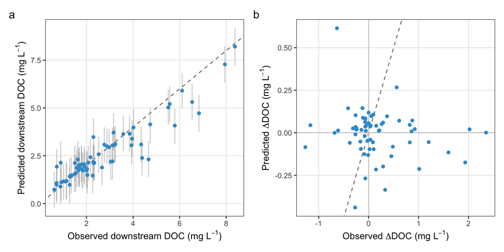

Figure 7: **Hold-out test of the downstream-DOC SCM.** The model was refitted on 80% of the streams and predicts the other 20%, which it has never seen. (a) Predicted (posterior mean, with 90% predictive interval) against observed downstream DOC at the unseen streams; dashed line: 1:1. (b) The derived local response, predicted downstream DOC minus upstream DOC, against the observed ΔDOC at the same samplings. $\Delta\text{DOC}_s$ is defined in Table 1.

```r
if (have_hold) {
  pa <- ggplot(tibble(y = y_h, mu = mu_h, lo = q_h[1, ], hi = q_h[2, ]), aes(y, mu)) +
    geom_abline(slope = 1, intercept = 0, linetype = "dashed", colour = "grey45") +
    geom_linerange(aes(ymin = lo, ymax = hi), colour = "grey70", alpha = .6) + geom_point(size = 1.6, colour = "#3B9AD1") +
    labs(x = expression("Observed downstream DOC (mg "*L^-1*")"), y = expression("Predicted downstream DOC (mg "*L^-1*")")) +
    theme_bw(base_size = 12) + theme(panel.grid.minor = element_blank())
  pb <- ggplot(tibble(o = d_obs_h, p = d_pred_h), aes(o, p)) +
    geom_abline(slope = 1, intercept = 0, linetype = "dashed", colour = "grey45") +
    geom_hline(yintercept = 0, colour = "grey80") + geom_vline(xintercept = 0, colour = "grey80") +
    geom_point(size = 1.6, colour = "#3B9AD1") +
    labs(x = expression("Observed "*Delta*"DOC (mg "*L^-1*")"), y = expression("Predicted "*Delta*"DOC (mg "*L^-1*")")) +
    theme_bw(base_size = 12) + theme(panel.grid.minor = element_blank())
  figH <- pa + pb + plot_annotation(tag_levels = "a")
  ggsave(here("results", "figures", "plan", "fig_holdout.png"), figH, width = 9, height = 4.5, dpi = 300)
  figH
}
```

**ImportantKey message of Figure 7, and what the manuscript may claim**

- **Downstream DOC at an unseen stream is predictable.** Hold-out R² = 0.84, RMSE 0.7 mg L⁻¹ (spread of the data 1.8), 90% predictive intervals containing 87% of the unseen observations — calibrated.
- **No overfitting.** In-sample R² 0.46, leave-one-out 0.45 (full model); 0.43 in sample for the hold-out fit. The R² on all streams is capped by a few very high concentrations in the heavy tail (RMSE 2.7 against a spread of 3.7), not by unseen streams.
- **The local change is not predictable.** Derived ΔDOC: hold-out R² = -0.18, RMSE 0.70 against 0.64 for predicting its mean.
- **Implication.** Almost all predictive skill is inheritance (downstream DOC is 95% upstream DOC). The manuscript can claim that the model predicts downstream DOC at unsampled Swiss streams from the upstream concentration and the measured drivers, and that the beaver-mediated change will be small relative to that inherited concentration and of stream-specific sign — it cannot claim to forecast *where* a stream becomes a source or a sink from dams, residence time or solar radiation alone (Q2, Q4).

# 9. Structural and causal sensitivity

The SCM of Q2 rests on causal assumptions that the data cannot fully verify: the arrows we drew, the arrows we left out, and the absence of unmeasured common causes. This section tests those assumptions in the tradition of Shipley (2016) and Grace’s causal-knowledge analysis: alternative structures (A), unmeasured confounding (B), relationships the DAG says must be null (C), robustness to modelling choices (D), and the qualitative causal-knowledge table (E). One fact conditions everything below: **the primary producers were measured at 16 streams, all in summer, and at none of them was the water residence time measured.** The producer paths therefore rest on 16 samplings, and the water-residence-time → producer paths are informed only by the priors and the imputation model. The sensitivity analyses say how much that matters.

**Manuscript placement: Appendix S1 (Figures S14–S17, Table S2), with one paragraph in the Methods.**

## A. Alternative DAGs

Four structures, all keeping the mediator core of Figure 1b:

- **DAG 0** — the manuscript’s model.
- **DAG 1** — upstream DOC also drives the primary producers (upstream DOC → phytoplankton, macrophytes): a DOC-rich inflow could feed or shade the producers.
- **DAG 2** — solar radiation acts directly on downstream DOC (photodegradation), not only through the producers.
- **DAG 3** — season is a common cause of the producers and of downstream DOC, left unblocked in DAG 0.

Each DAG implies conditional independencies that can be checked on the data with `dagitty` (Shipley 2016). Each test is run on the rows complete for the variables it involves, and reported as the partial correlation with its 95% interval (the only frequentist quantity in this document, kept because the test is the standard one for this purpose). Structures that add an arrow *remove* an implied independence, so a DAG-0 independence that fails in the data, and that an alternative DAG does not imply, is evidence for that alternative.

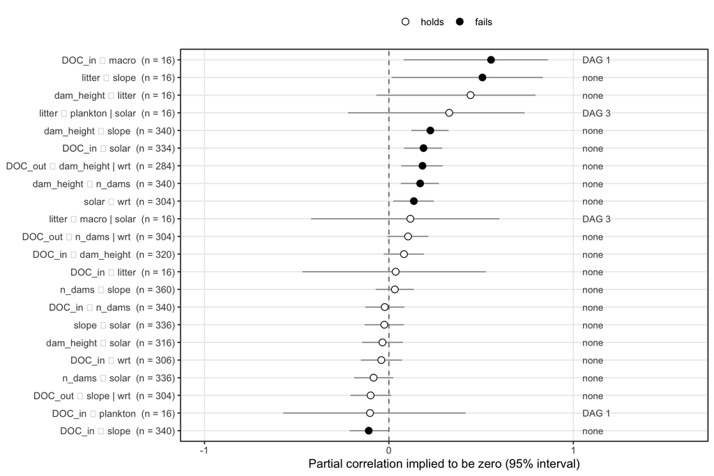

Figure 8: **Conditional independencies implied by DAG 0, tested on the data.** Each row is one independence the manuscript’s DAG implies (X ⊥ Y | Z); the point is the partial correlation on the rows complete for the variables involved, with its 95% interval and the number of samplings used. Filled points: the interval excludes zero (the independence fails). The right-hand label says which alternative DAG(s) would drop that independence, i.e. which alternative a failure supports. Tests with fewer than 10 complete rows are not run.

```r
dag_txt <- list(
  dag0 = "dag { n_dams -> wrt; dam_height -> wrt; slope -> wrt; solar -> plankton; solar -> macro; solar -> litter;
           wrt -> plankton; wrt -> macro; wrt -> DOC_out; plankton -> DOC_out; macro -> DOC_out; litter -> DOC_out; DOC_in -> DOC_out }",
  dag1 = "dag { n_dams -> wrt; dam_height -> wrt; slope -> wrt; solar -> plankton; solar -> macro; solar -> litter;
           wrt -> plankton; wrt -> macro; wrt -> DOC_out; plankton -> DOC_out; macro -> DOC_out; litter -> DOC_out; DOC_in -> DOC_out;
           DOC_in -> plankton; DOC_in -> macro }",
  dag2 = "dag { n_dams -> wrt; dam_height -> wrt; slope -> wrt; solar -> plankton; solar -> macro; solar -> litter;
           wrt -> plankton; wrt -> macro; wrt -> DOC_out; plankton -> DOC_out; macro -> DOC_out; litter -> DOC_out; DOC_in -> DOC_out;
           solar -> DOC_out }",
  dag3 = "dag { n_dams -> wrt; dam_height -> wrt; slope -> wrt; solar -> plankton; solar -> macro; solar -> litter;
           wrt -> plankton; wrt -> macro; wrt -> DOC_out; plankton -> DOC_out; macro -> DOC_out; litter -> DOC_out; DOC_in -> DOC_out;
           season -> plankton; season -> macro; season -> litter; season -> DOC_out }")
gs <- lapply(dag_txt, dagitty)
dd <- m6 |> transmute(n_dams = n_dams_z, dam_height = dam_height_z, slope = slope_z, solar = solar_z,
                      plankton = plankton_abun_z, macro = macrophy_abun_z, litter = cover_litter_z, wrt = water_res_time_z,
                      DOC_out, DOC_in = DOC_input, season = as.numeric(season == "summer"))
ci_lab <- function(x) paste0(x$X, " ⊥ ", x$Y, if (length(x$Z)) paste0(" | ", paste(unlist(x$Z), collapse = ", ")) else "")
ci0 <- impliedConditionalIndependencies(gs$dag0)
implied_by <- function(g, lab) lab %in% sapply(impliedConditionalIndependencies(g), ci_lab)
tests <- lapply(ci0, function(x) {
  v <- unlist(c(x$X, x$Y, x$Z)); sub <- dd[complete.cases(dd[, v]), v, drop = FALSE]
  n <- nrow(sub); lab <- ci_lab(x)
  out <- tibble(test = lab, n = n, r = NA_real_, lo = NA_real_, hi = NA_real_)
  if (n >= 10 && all(apply(sub, 2, sd) > 0)) {
    t <- tryCatch(localTests(gs$dag0, sub, type = "cis", tests = list(x)), error = function(e) NULL)
    if (!is.null(t)) out <- tibble(test = lab, n = n, r = t$estimate, lo = t$`2.5%`, hi = t$`97.5%`) }
  out$dropped_by <- paste(names(gs)[-1][!sapply(gs[-1], implied_by, lab = lab)], collapse = ", ")
  out })
tests <- bind_rows(tests) |> filter(!is.na(r)) |>
  mutate(fails = lo > 0 | hi < 0, dropped_by = ifelse(dropped_by == "", "none", gsub("dag", "DAG ", dropped_by)),
         test = fct_reorder(paste0(test, "  (n = ", n, ")"), r))
ggplot(tests, aes(x = r, y = test)) +
  geom_vline(xintercept = 0, linetype = "dashed", colour = "grey45") +
  geom_linerange(aes(xmin = lo, xmax = hi), colour = "grey60") +
  geom_point(aes(fill = fails), shape = 21, size = 2.6, colour = "black") +
  geom_text(aes(x = 1.05, label = dropped_by), hjust = 0, size = 3, colour = "grey30") +
  scale_fill_manual(values = c(`TRUE` = "black", `FALSE` = "white"), labels = c(`TRUE` = "fails", `FALSE` = "holds"), name = NULL) +
  coord_cartesian(xlim = c(-1, 1.6), clip = "off") +
  labs(x = "Partial correlation implied to be zero (95% interval)", y = NULL) +
  theme_bw(base_size = 11) + theme(panel.grid.minor = element_blank(), legend.position = "top") -> p_tests
ggsave(here("results", "figures", "plan", "fig_dag_tests.png"), p_tests, width = 9, height = 6, dpi = 300, bg = "white"); p_tests
```

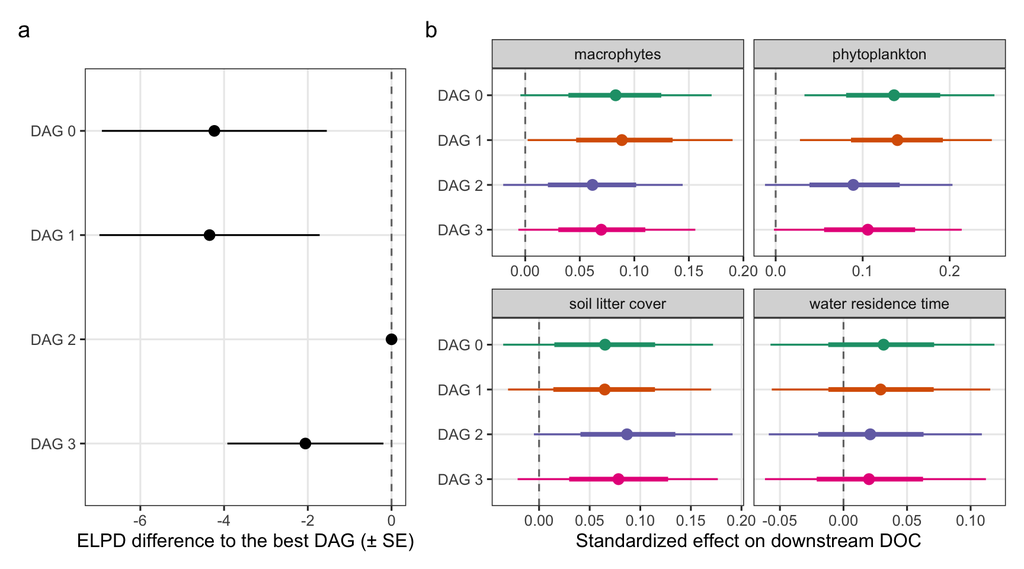

Figure 9: **The four DAGs fitted as multivariate models.** (a) Out-of-sample fit for downstream DOC by PSIS-LOO: expected log predictive density relative to the best model (0 = best), with standard error; a difference smaller than about 4 is not meaningful. (b) The mediator effects on downstream DOC under each structure: posterior median with 66% and 95% credible intervals. Fits with 4 chains × 2500 post-warm-up draws; max R-hat in the caption of the callout.

```r
if (have_sens) {
  cmp <- as.data.frame(SENS$loo_compare); if (!"model" %in% names(cmp)) cmp$model <- rownames(cmp)
  cmp <- cmp |> select(model, elpd_diff, se_diff) |> mutate(model = factor(gsub("dag", "DAG ", model), levels = paste("DAG", 0:3)))
  pa <- ggplot(cmp, aes(x = elpd_diff, y = fct_rev(model))) +
    geom_vline(xintercept = 0, linetype = "dashed", colour = "grey45") +
    geom_pointrange(aes(xmin = elpd_diff - se_diff, xmax = elpd_diff + se_diff), size = .5) +
    labs(x = "ELPD difference to the best DAG (± SE)", y = NULL) + theme_bw(base_size = 12) + theme(panel.grid.minor = element_blank())
  eff <- bind_rows(lapply(c("dag0","dag1","dag2","dag3"), function(nm) as_tibble(SENS$models[[nm]]$draws) |>
    pivot_longer(everything(), names_to = "par", values_to = "v") |> mutate(model = gsub("dag", "DAG ", nm)))) |>
    filter(par != "bsp_DOCout_miDOC_input") |> mutate(par = factor(med_names[par], levels = med_names[-1]))
  pb <- ggplot(eff, aes(x = v, y = fct_rev(factor(model)), colour = model)) +
    geom_vline(xintercept = 0, linetype = "dashed", colour = "grey45") +
    stat_pointinterval(.width = c(.66, .95), point_interval = "median_qi") +
    facet_wrap(~ par, ncol = 2, scales = "free_x") + scale_colour_brewer(palette = "Dark2", guide = "none") +
    labs(x = "Standardized effect on downstream DOC", y = NULL) + theme_bw(base_size = 12) + theme(panel.grid.minor = element_blank())
  p_cmp <- pa + pb + plot_layout(widths = c(1, 1.6)) + plot_annotation(tag_levels = "a")
  ggsave(here("results", "figures", "plan", "fig_dag_compare.png"), p_cmp, width = 9, height = 5, dpi = 300, bg = "white"); p_cmp
} else cat("DAG fits not yet available (notebook/R/dag_sensitivity.R).")
```

**ImportantConclusions — A. Alternative DAGs**

## B. Unmeasured confounding of the mediator → DOC paths

How strong would an unobserved common cause of a producer and downstream DOC have to be to erase the producer’s effect? Following Cinelli & Hazlett (2020) as implemented in `sensemakr`, the outcome equation is fitted as a linear model on the 16 producer streams (the only rows with the producers; water residence time is absent there and cannot be included), with solar radiation as the benchmark covariate: the contour plots show the adjusted effect for every combination of confounder strength (its partial R² with the treatment and with the outcome), and the marks show a confounder as strong as one, two and three times solar radiation. The **robustness value** is the strength (partial R² with both) at which the effect reaches zero.

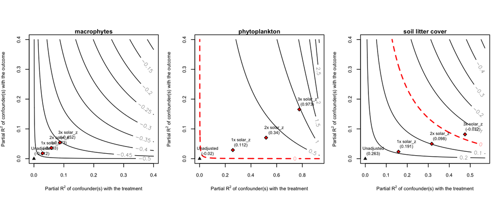

Figure 10: **Robustness of each producer → downstream DOC path to an unmeasured confounder.** Contours: the adjusted effect of the producer on downstream DOC for a confounder with the given partial R² with the producer (x) and with downstream DOC (y); the triangle is the unadjusted estimate; the red marks are confounders 1×, 2× and 3× as strong as solar radiation. Linear outcome equation on the 16 producer streams (summer). Note that this linear fit does not carry the priors, the measurement error or the water-residence-time path of the SCM — it is the sensitivity of the raw 16-stream relationship.

```r
library(sensemakr)
dl <- m6 |> filter(!is.na(plankton_abun_z)) |> select(DOC_out, DOC_input, macrophy_abun_z, plankton_abun_z, cover_litter_z, solar_z)
lmo <- lm(DOC_out ~ DOC_input + macrophy_abun_z + plankton_abun_z + cover_litter_z + solar_z, data = dl)
paths <- c(macrophy_abun_z = "macrophytes", plankton_abun_z = "phytoplankton", cover_litter_z = "soil litter cover")
rv <- sapply(names(paths), function(tr) { s <- sensemakr(lmo, treatment = tr, benchmark_covariates = "solar_z", kd = 1:3)
  c(est = s$sensitivity_stats$estimate, rv = s$sensitivity_stats$rv_q, r2 = s$sensitivity_stats$r2yd.x, r2_solar = s$bounds$r2dz.x[1]) })
draw_sm <- function() { par(mfrow = c(1, 3), mar = c(4, 4, 3, 1))
  for (tr in names(paths)) { s <- sensemakr(lmo, treatment = tr, benchmark_covariates = "solar_z", kd = 1:3)
    ovb_contour_plot(s, sensitivity.of = "estimate", main = paths[tr]) } }
png(here("results", "figures", "plan", "fig_sensemakr.png"), width = 9, height = 4, units = "in", res = 300); draw_sm(); invisible(dev.off())
draw_sm()
```

**ImportantConclusions — B. Unmeasured confounding**

- **The raw 16-stream relationship is not the SCM’s.** In the linear outcome equation the estimates are -0.51 (macrophytes), -0.02 (phytoplankton) and 0.26 (litter), against +0.08, +0.14 and +0.07 in the SCM. The SCM’s positive producer effects are therefore carried substantially by the informative priors (Normal(0.2, 0.075) on each producer path) and by the hierarchical structure, not by these 16 samplings alone. This is the single most important sensitivity result of the section, and it is confirmed by the prior-sensitivity fits in D.
- **Robustness values** (strength a confounder needs to erase the raw effect): macrophytes 0.45, litter 0.21, phytoplankton 0.01; solar radiation, the strongest measured covariate, explains only 3%–26% of the residual variance of any producer, so a confounder several times stronger than solar would be needed to remove the macrophyte or litter relationship, and almost none to remove the phytoplankton one.
- **Water residence time cannot be assessed** this way: it was never measured at a producer stream.
- **What the manuscript should say:** the producer → DOC paths are consistent with the literature-based priors and are not overturned by plausible confounding, but with 16 summer samplings they are prior-informed estimates rather than data-driven ones; the Methods should state the prior for each path and D should be cited.

## C. Falsification tests and a placebo outcome

The DAG says some relationships must be absent. If they are present, either the DAG or the data are wrong somewhere. Three implied nulls among the exogenous drivers, tested as Bayesian regressions on all samplings, and one placebo outcome: upstream DOC, which lies above the dams and cannot be affected by beaver-engineering — if the number of dams, the dam height or the water residence time “predicted” upstream DOC, it would reveal a confounder (a landscape gradient that sets both the dams and the DOC).

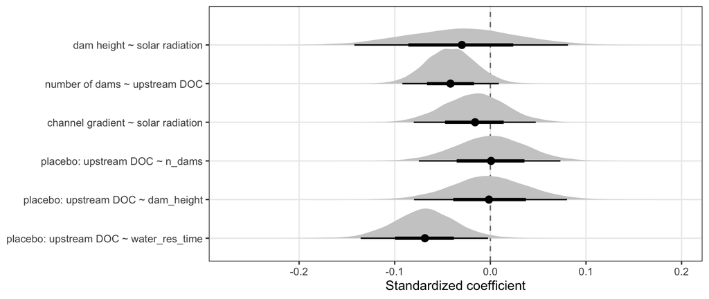

Figure 11: **Relationships the DAG says must be null.** Posterior distributions of the standardized coefficients of four Bayesian Student-t regressions on all samplings (Normal(0, 1) priors on the slopes); point: median, bars: 66% and 95% credible intervals; dashed line: zero. The last three rows are the placebo outcome — upstream DOC regressed on the beaver-engineering variables, which cannot causally affect it.

```r
nc_fit <- function(f, tag) brm(f, data = m6, family = student(), prior = c(prior(normal(0, 1), class = "b")),
  chains = 4, iter = 3000, warmup = 1000, seed = 7, backend = "cmdstanr", refresh = 0,
  file = here("results", "models_fit", paste0("negctrl_", tag)))
nc <- list(
  `dam height ~ solar radiation`      = nc_fit(dam_height_z ~ solar_z, "dh_solar"),
  `number of dams ~ upstream DOC`     = nc_fit(n_dams_z ~ DOC_input_z, "nd_docin"),
  `channel gradient ~ solar radiation`= nc_fit(slope_z ~ solar_z, "slope_solar"),
  `placebo: upstream DOC ~ dams, height, residence time` = nc_fit(DOC_input_z ~ n_dams_z + dam_height_z + water_res_time_z, "placebo"))
nc_draws <- bind_rows(lapply(names(nc), function(nm) { d <- as_draws_df(nc[[nm]]); b <- grep("^b_", names(d), value = TRUE); b <- b[b != "b_Intercept"]
  as_tibble(d[, b]) |> pivot_longer(everything(), names_to = "coef", values_to = "v") |>
    mutate(test = nm, coef = sub("^b_", "", coef), label = if (length(b) == 1) nm else paste0("placebo: upstream DOC ~ ", gsub("_z$", "", coef))) }))
nc_sum <- nc_draws |> group_by(label) |> summarise(med = median(v), lo = quantile(v, .025), hi = quantile(v, .975), p_pos = mean(v > 0))
ggplot(nc_draws, aes(x = v, y = fct_rev(factor(label, levels = unique(label))))) +
  geom_vline(xintercept = 0, linetype = "dashed", colour = "grey45") +
  stat_halfeye(.width = c(.66, .95), point_interval = "median_qi", fill = "grey80") +
  labs(x = "Standardized coefficient", y = NULL) + theme_bw(base_size = 12) + theme(panel.grid.minor = element_blank()) -> p_nc
ggsave(here("results", "figures", "plan", "fig_negative_controls.png"), p_nc, width = 9, height = 3.8, dpi = 300, bg = "white"); p_nc
```

**ImportantConclusions — C. Falsification tests**

- **channel gradient ~ solar radiation:** -0.02 [-0.08, 0.05], P(> 0) = 0.30 — consistent with the implied null.
- **dam height ~ solar radiation:** -0.03 [-0.14, 0.08], P(> 0) = 0.29 — consistent with the implied null.
- **number of dams ~ upstream DOC:** -0.04 [-0.09, 0.01], P(> 0) = 0.05 — consistent with the implied null.
- **placebo: upstream DOC ~ dam_height:** -0.00 [-0.08, 0.08], P(> 0) = 0.48 — consistent with the implied null.
- **placebo: upstream DOC ~ n_dams:** 0.00 [-0.07, 0.07], P(> 0) = 0.51 — consistent with the implied null.
- **placebo: upstream DOC ~ water_res_time:** -0.07 [-0.14, -0.00], P(> 0) = 0.02 — **the implied null fails**.
- **Placebo outcome:** the largest association between a beaver-engineering variable and upstream DOC is water_res_time (-0.07 SD); credibly non-zero but small. Any confounding of the dam → residence time → DOC chain by the catchment’s DOC regime is therefore at most of that size, an order of magnitude below the inheritance slope.
- **Reading:** a failed null among the exogenous drivers (dams, gradient, solar) means those drivers share a landscape cause — which the SCM tolerates, because they are not on a causal path to each other, but which a reader should know. A failed placebo would mean that the beaver-engineering variables are confounded with the DOC regime of the catchment; the result above says whether that is the case.

## D. Robustness to modelling choices

Two checks are already in section 4 (outcome parameterization; inheritance slope fixed at 1). Two remain: the prior scale, and spatial autocorrelation of the residuals.

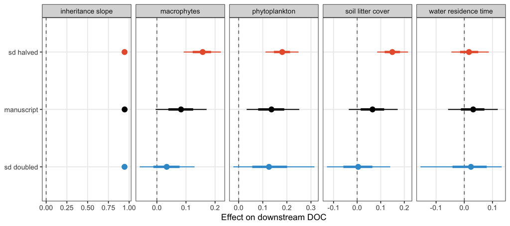

Figure 12: **Prior sensitivity.** Mediator effects on downstream DOC when the standard deviation of every informative prior is halved, kept as in the manuscript, or doubled; posterior median with 66% and 95% credible intervals. A path whose estimate follows the prior scale is prior-driven; a path that stays put is data-driven.

```r
if (have_sens) {
  ps <- bind_rows(lapply(c(prior_half = "prior_half", manuscript = "dag0", prior_double = "prior_double"), function(nm) as_tibble(SENS$models[[nm]]$draws) |>
    pivot_longer(everything(), names_to = "par", values_to = "v")), .id = "prior") |>
    mutate(prior = factor(prior, levels = c("prior_half", "manuscript", "prior_double"), labels = c("sd halved", "manuscript", "sd doubled")),
           par = factor(med_names[par], levels = med_names))
  ggplot(ps, aes(x = v, y = fct_rev(prior), colour = prior)) +
    geom_vline(xintercept = 0, linetype = "dashed", colour = "grey45") +
    stat_pointinterval(.width = c(.66, .95), point_interval = "median_qi") +
    facet_wrap(~ par, scales = "free_x", ncol = 5) + scale_colour_manual(values = c("#E8603C", "black", "#3B9AD1"), guide = "none") +
    labs(x = "Effect on downstream DOC", y = NULL) + theme_bw(base_size = 11) + theme(panel.grid.minor = element_blank()) -> p_ps
  ggsave(here("results", "figures", "plan", "fig_prior_sens.png"), p_ps, width = 10, height = 4, dpi = 300, bg = "white"); p_ps
} else cat("Prior-sensitivity fits not yet available.")
```

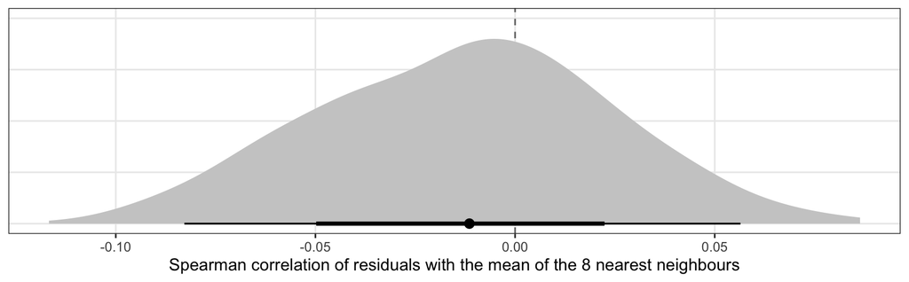

Figure 13: **Spatial autocorrelation of the residuals of downstream DOC.** For each posterior draw, the Spearman correlation between each sampling’s residual (observed minus expected downstream DOC) and the mean residual of its 8 nearest neighbouring samplings, using the stream coordinates; point: median, bars: 66% and 95% credible intervals; dashed line: no spatial autocorrelation.

```r
P2 <- readRDS(here("results", "scm_downstream_pred.rds")); obs2 <- P2$obs
lon <- m6$x_upstream[obs2]; lat <- m6$y_upstream[obs2]; okc <- !is.na(lon)
kmx2 <- (lon - mean(lon, na.rm = TRUE)) * 111.32 * cos(mean(lat, na.rm = TRUE) * pi / 180); kmy2 <- (lat - mean(lat, na.rm = TRUE)) * 110.57
D2 <- as.matrix(dist(cbind(kmx2[okc], kmy2[okc]))); diag(D2) <- Inf
nb2 <- t(apply(D2, 1, function(r) order(r)[1:8]))
resid <- sweep(-P2$ep_sub[, obs2][, okc], 2, -P2$y[okc])
rho_res <- apply(resid, 1, function(r) cor(r, rowMeans(matrix(r[as.vector(nb2)], nrow = length(r))), method = "spearman"))
ggplot(tibble(rho = rho_res), aes(x = rho, y = 1)) +
  geom_vline(xintercept = 0, linetype = "dashed", colour = "grey45") +
  stat_halfeye(.width = c(.66, .95), point_interval = "median_qi", fill = "grey80") +
  labs(x = "Spearman correlation of residuals with the mean of the 8 nearest neighbours", y = NULL) +
  theme_bw(base_size = 12) + theme(panel.grid.minor = element_blank(), axis.text.y = element_blank(), axis.ticks.y = element_blank())
```

**ImportantConclusions — D. Modelling choices**

- **Prior scale:** the inheritance slope does not move (0.94, 0.95, 0.94 from halved to doubled sd). The producer paths move with the prior: the largest shift is soil litter cover, from 0.15 (sd halved) to 0.00 (sd doubled). The path that keeps its sign when the prior is loosened is phytoplankton (0.13 with sd doubled); macrophytes and litter follow the prior. With 16 summer samplings, the producer effects are prior-informed estimates, the same conclusion as B, reached from the other side.
- **Spatial residuals:** the residual neighbour correlation is -0.01 [-0.08, 0.06] — no spatial autocorrelation is left in downstream DOC once upstream DOC and the drivers are in the model, so the stream random effect is doing its job and a spatial term is not needed.
- Together with section 4: outcome parameterization, inheritance slope, prior scale and space — the inheritance and the *absence* of a consistent local effect are robust; the *sign* of each producer path is where the model leans on prior knowledge.

## E. Causal knowledge analysis

The qualitative frame the quantitative checks sit in (after Grace’s causal-knowledge analysis; **the wording of the eight questions must be checked against the paper before this goes into Appendix S1**).

Table 2: Causal knowledge analysis of the beaver–DOC system.

[output not shown]

**ImportantConclusions — E. Causal knowledge analysis**

- The structure of Q2 is well supported where the data are dense (inheritance, direction, dams → residence time) and prior-dependent where they are thin (producers).
- The manuscript should say so in one Methods paragraph: which arrows were tested and how (A, C), how strong a confounder would have to be (B), and that the producer effects follow the prior scale (D) — with Appendix S1 Figures S14–S17 and Table S2.
- This is not a weakness to hide: it is the honest statement of what a national survey with a 16-stream mechanistic subset can and cannot identify, and it points to the next study — residence time and producers measured at the same streams, in both seasons.

# 10. Q5 — Pathway decomposition of the local modification

**Question:** Why do some streams enrich and others deplete DOC, and why does the same stream change role between seasons?

The regional analysis (section 7) says an inherited DOC signal exists; the SCM (section 4) says which local processes modify it. What neither says is *why* a given stream ends up enriching or depleting, and why the same stream can change role between winter and summer. The approach is to use the fitted SCM itself: for every sampling, season and posterior draw, split the predicted local modification (predicted downstream DOC minus upstream DOC) into the contribution of each modelled pathway, and compare the balance between enriching and depleting streams and between seasons.

From Equation 1 the local modification of sampling $i$ in draw $d$ is a sum of named parts:

$$\begin{aligned}
L^{(d)}_i \;=\; \mu^{(d)}_i - \text{DOC}_{up,i}
&= \underbrace{(\beta_{inh}^{(d)} - 1)\,\text{DOC}_{up,i}}_{\text{inheritance shortfall}}
+ \underbrace{\beta^{(d)}_{pla} M_{pla,i}}_{\text{phytoplankton}}
+ \underbrace{\beta^{(d)}_{mac} M_{mac,i}}_{\text{macrophytes}} \\
&\quad + \underbrace{\beta^{(d)}_{lit} M_{lit,i}}_{\text{litter}}
+ \underbrace{\beta^{(d)}_{wrt} M_{wrt,i}}_{\text{hydrology}}
+ \underbrace{\alpha^{(d)} + u^{(d)}_{site(i)}}_{\text{unresolved}}
\end{aligned}
\tag{2}$$

The last term is what the model cannot attribute to a measured pathway: the intercept and the stream’s own effect. It is reported as an **unresolved net removal/transformation component**, not assigned to any process. Two limits are stated before the results, because they decide how much this analysis can say:

- **The producers were measured at 16 streams, in summer only, and water residence time at none of them.** At every other sampling the mediator values in Equation 2 are the draw’s *imputed* values, generated by the mediator sub-models from solar radiation and residence time — and, because the model is joint, partly from the outcome itself. The pathway contributions at imputed samplings are therefore model-implied, not measured, and can partly re-label the residual. The decomposition is shown for all samplings and, separately, for the 16 measured streams.
- **The decomposition is only as good as the SCM’s paths**, and section 9 showed the producer effects to be prior-informed.

**Manuscript placement: Appendix S1 (Figure S18), with two sentences in the Discussion.**

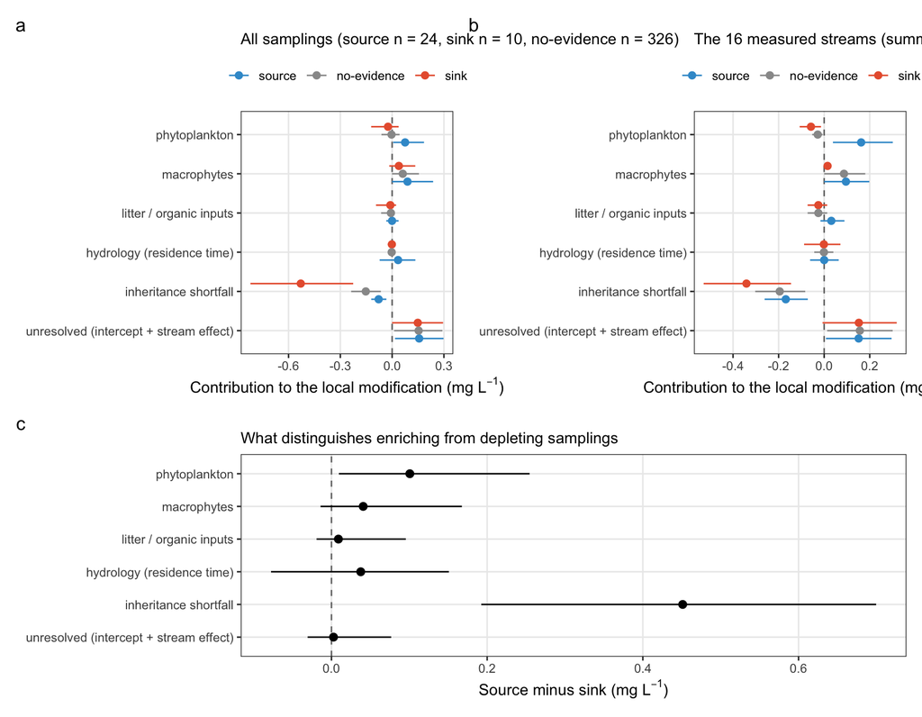

Figure 14: **What the modelled pathways contribute to the local modification, in enriching and depleting samplings.** Posterior mean contribution (mg L⁻¹) of each component of Equation 2 to the predicted local modification, averaged over the samplings classified as source (P(L > 0) > 0.90), sink (P(L < 0) > 0.90) or no-evidence; point: posterior median, bars: 66% and 95% credible intervals. (a) All samplings (mediators imputed where not measured). (b) The 16 streams where the producers were measured. (c) Source-minus-sink difference per component, all samplings; a component whose interval excludes zero is one that distinguishes enriching from depleting streams. Variables defined in Table 1; $L$ is the derived local response of the SCM.

```r
if (have_dec) {
  mk <- function(df) df |> mutate(component = factor(component, levels = rev(comp_lv)), class = factor(class, levels = c("source", "no-evidence", "sink")))
  pl <- function(df, ttl) ggplot(mk(df), aes(x = med, y = component, colour = class)) +
    geom_vline(xintercept = 0, linetype = "dashed", colour = "grey45") +
    geom_pointrange(aes(xmin = lo, xmax = hi), position = position_dodge(width = .6), size = .35) +
    scale_colour_manual(values = c(source = "#3B9AD1", `no-evidence` = "grey60", sink = "#E8603C"), name = NULL) +
    scale_y_discrete(labels = comp_lab) +
    labs(x = expression("Contribution to the local modification (mg "*L^-1*")"), y = NULL, subtitle = ttl) +
    theme_bw(base_size = 11) + theme(panel.grid.minor = element_blank(), legend.position = "top")
  pa <- pl(DEC$summ_all, sprintf("All samplings (source n = %d, sink n = %d, no-evidence n = %d)", DEC$n_class["source"], DEC$n_class["sink"], DEC$n_class["no-evidence"]))
  pb <- pl(DEC$summ_meas, "The 16 measured streams (summer)")
  pc <- ggplot(DEC$diff_all |> mutate(component = factor(component, levels = rev(comp_lv))), aes(x = med, y = component)) +
    geom_vline(xintercept = 0, linetype = "dashed", colour = "grey45") +
    geom_pointrange(aes(xmin = lo, xmax = hi), size = .4) + scale_y_discrete(labels = comp_lab) +
    labs(x = expression("Source minus sink (mg "*L^-1*")"), y = NULL, subtitle = "What distinguishes enriching from depleting samplings") +
    theme_bw(base_size = 11) + theme(panel.grid.minor = element_blank())
  fig_dec <- (pa + pb) / pc + plot_layout(heights = c(1.2, 1)) + plot_annotation(tag_levels = "a")
  ggsave(here("results", "figures", "plan", "fig_decomp.png"), fig_dec, width = 11, height = 7, dpi = 300, bg = "white"); fig_dec
} else cat("Decomposition not yet computed (notebook/R/pathway_decomposition.R).")
```

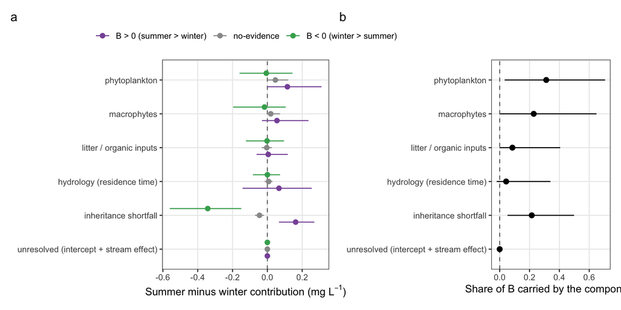

Figure 15: **The seasonal change of each pathway contribution, by the sign of the beaver seasonal modification B.** For every stream with both seasons, the summer-minus-winter change of each component of Equation 2, averaged over the streams whose B (derived from the SCM) is credibly positive, credibly negative, or no-evidence; point: posterior median, bars: 66% and 95% credible intervals. Right: the share of B carried by each component — the posterior slope of the component’s seasonal change on B across streams (the shares sum to one).

```r
if (have_dec) {
  lvB <- c("B > 0 (summer > winter)", "no-evidence", "B < 0 (winter > summer)")
  pa <- ggplot(DEC$seas |> mutate(component = factor(component, levels = rev(comp_lv)), classB = factor(classB, levels = lvB)),
               aes(x = med, y = component, colour = classB)) +
    geom_vline(xintercept = 0, linetype = "dashed", colour = "grey45") +
    geom_pointrange(aes(xmin = lo, xmax = hi), position = position_dodge(width = .6), size = .35) +
    scale_colour_manual(values = c(`B > 0 (summer > winter)` = "#8856A7", `no-evidence` = "grey60", `B < 0 (winter > summer)` = "#41AB5D"), name = NULL) +
    scale_y_discrete(labels = comp_lab) +
    labs(x = expression("Summer minus winter contribution (mg "*L^-1*")"), y = NULL) +
    theme_bw(base_size = 11) + theme(panel.grid.minor = element_blank(), legend.position = "top")
  pb <- ggplot(DEC$share |> mutate(component = factor(component, levels = rev(comp_lv))), aes(x = med, y = component)) +
    geom_vline(xintercept = 0, linetype = "dashed", colour = "grey45") +
    geom_pointrange(aes(xmin = lo, xmax = hi), size = .4) + scale_y_discrete(labels = comp_lab) +
    labs(x = "Share of B carried by the component", y = NULL) + theme_bw(base_size = 11) + theme(panel.grid.minor = element_blank())
  fig_ds <- pa + pb + plot_layout(widths = c(1.4, 1)) + plot_annotation(tag_levels = "a")
  ggsave(here("results", "figures", "plan", "fig_decomp_season.png"), fig_ds, width = 11, height = 4.5, dpi = 300, bg = "white"); fig_ds
}
```

**ImportantKey message of Figure 14 and Figure 15**

- **Where the variation in the local modification comes from (share of variance across samplings):** inheritance shortfall 29% [7–60%]; phytoplankton 26% [3–63%]; macrophytes 18% [0–56%]; litter / organic inputs 7% [-0–33%]; hydrology (residence time) 4% [-2–29%]; unresolved (intercept + stream effect) 4% [-0–32%].
- **What distinguishes sources from sinks (source minus sink, mg L⁻¹):** inheritance shortfall 0.45 [0.19, 0.70]; phytoplankton 0.10 [0.01, 0.25]; macrophytes 0.04 [-0.01, 0.17]; litter / organic inputs 0.01 [-0.02, 0.10]; hydrology (residence time) 0.04 [-0.08, 0.15]; unresolved (intercept + stream effect) 0.00 [-0.03, 0.08].
- **What carries the seasonal change B (share of B):** inheritance shortfall 21% [5–50%]; phytoplankton 31% [3–71%]; macrophytes 23% [0–65%]; litter / organic inputs 9% [-0–41%]; hydrology (residence time) 4% [-2–34%]; unresolved (intercept + stream effect) 0% [0–0%]; 180 samplings-pairs with both seasons in the SCM data (m6), of which 6 have B credibly positive and 3 credibly negative.
- **Implication: the sign is set first by what comes in, then by phytoplankton.** The component that separates sources from sinks is the inheritance shortfall (0.45 mg L⁻¹ more negative in sinks): the streams that deplete are the ones receiving the most DOC, where a 5% shortfall on a large inherited concentration outweighs the biological additions. Phytoplankton is the only measured pathway that also separates them (0.10 mg L⁻¹, credible), and at the 16 measured streams its contribution is clearly positive in sources and negative in sinks (Figure 14 b). Macrophytes, litter and residence time do not distinguish the two.
- **Implication for the seasons.** The summer-minus-winter change B is carried by the producers (phytoplankton 31%, macrophytes 23%) and by the seasonal change of the inherited state itself (21%): streams whose B is positive gain phytoplankton and macrophyte contributions in summer, streams whose B is negative lose through the inheritance term (their upstream DOC rises more than the producers can add). The unresolved component carries none of the seasonal change **by construction** — the SCM has one stream effect for both seasons — so seasonal switching is forced onto the measured and imputed pathways; a season-specific stream effect would be needed to test whether unmeasured removal also changes with season.
- **What can and cannot be claimed.** With the producers imputed at all but 16 streams, the phytoplankton and macrophyte shares (26% and 18% of the variance) are model-implied outside those 16; the inheritance result rests on all 158 streams and is solid. The decomposition supports the framing — an inherited signal, locally modified, with enrichment where phytoplankton adds to a modest inflow and depletion where a rich inflow is not matched by production — but the removal side (mineralization, photodegradation) is unmeasured and appears here only as the 5% shortfall, which is why it must be described as unresolved net removal rather than attributed.

# 11. Methods figure

**Manuscript placement: main text, Figure 3 (both panels redrawn: panel a shows the 158 analysed streams, panel b shows $S$, $\Delta\text{DOC}_s$, $R_s$ and $F$ in place of the amplification-factor quantities).**

The chunk below draws panel (a) directly from the analysed data — the red dots are exactly the 158 streams, so map and analysis can never disagree — plus the 16 producer-abundance streams (black triangles; coordinates in `data/processed/producer_sites_coordinates.csv`, taken from the field-campaign site list). Panel (b) is the schematic of the derived variables.

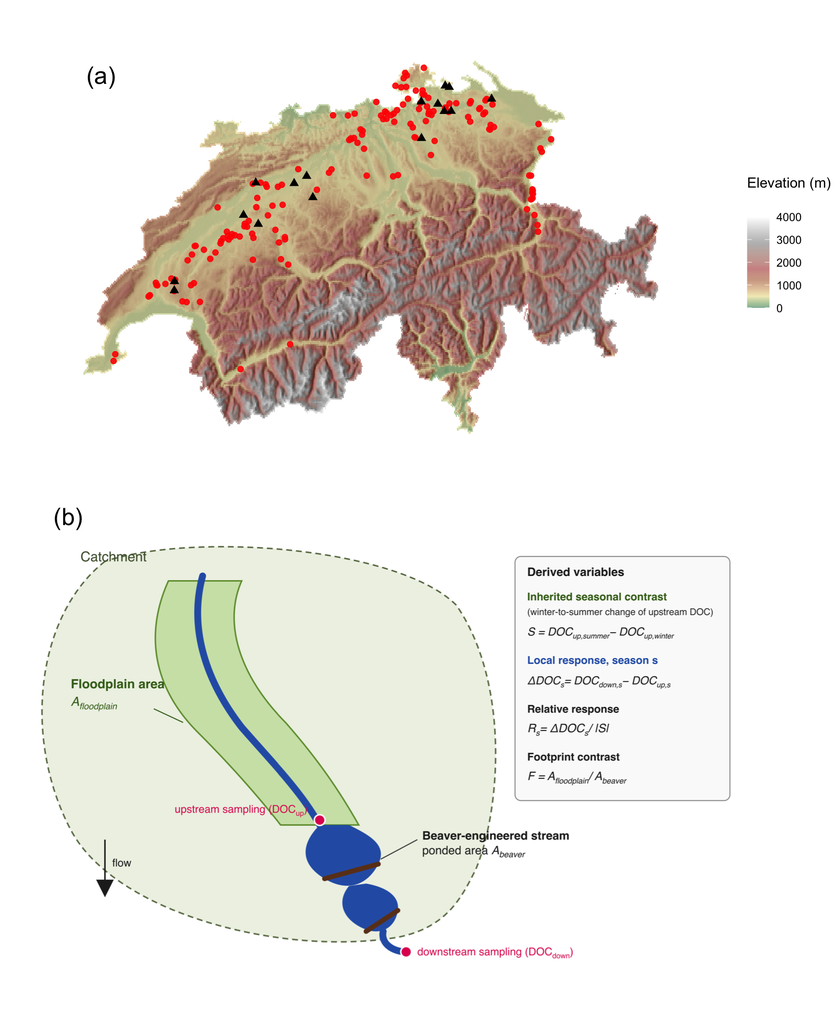

Figure 16: **Sampling design and derived variables.** (a) Sampling locations across Switzerland (elevation background): red dots are the 158 analysed streams; black triangles are the 16 streams where primary producer abundance was sampled. Water was sampled upstream of the first and downstream of the last beaver dam of each stream, once in winter and once in summer. (b) Schematic of the derived variables: the inherited seasonal contrast $S$ is generated over the floodplain area $A_\text{floodplain}$; the local response $\Delta\text{DOC}_s$ is measured across the beaver-engineered stream of ponded area $A_\text{beaver}$; the relative response is $R_s = \Delta\text{DOC}_s / \lvert S \rvert$ and the footprint contrast is $F = A_\text{floodplain} / A_\text{beaver}$. All variables are defined in Table 1.

```r
# panel (a): the 158 analysed streams (d, from the Q1 chunk) with coordinates,
# and the 16 producer-abundance streams from the field-campaign site list
pts  <- d |> distinct(site) |>
  left_join(read.csv(here("data", "processed", "m6.csv")) |> distinct(site, .keep_all = TRUE) |>
              select(site, lon = x_upstream, lat = y_upstream), by = "site")
prod <- read.csv(here("data", "processed", "producer_sites_coordinates.csv"))
# elevation background: Swiss DEM (30 arc-second, data/elevation/) with a
# hillshade underlay and a hypsometric tint, as in the original map
library(terra); library(tidyterra)
dem    <- rast(here("data", "elevation", "CHE_elv_msk.tif"))
hill   <- shade(terrain(dem, "slope", unit = "radians"),
                terrain(dem, "aspect", unit = "radians"), 40, 270)
greys  <- hcl.colors(1000, "Grays")
hillcol <- greys[round(scales::rescale(values(hill), to = c(1, 1000)))]
pmap <- ggplot() +
  geom_spatraster(data = hill, fill = hillcol, maxcell = Inf) +
  geom_spatraster(data = dem, maxcell = Inf) +
  scale_fill_hypso_tint_c(palette = "dem_poster", alpha = 0.5, na.value = NA, name = "Elevation (m)") +
  geom_point(data = pts, aes(lon, lat), colour = "red", size = 1.7, alpha = 0.9) +
  geom_point(data = prod, aes(longitude, latitude), colour = "black", size = 2.2, shape = 17) +
  annotate("text", x = 5.99, y = 47.75, label = "(a)", size = 6.5, hjust = 0) +
  theme_void() + theme(legend.position = "right")
# panel (b): the schematic, included as an image below the map
schem <- png::readPNG(here("results", "figures", "plan", "schematic_S_R_F.png"))
psch  <- ggplot() + annotation_custom(grid::rasterGrob(schem)) +
  annotate("text", x = 0.02, y = 0.97, label = "(b)", size = 6.5, hjust = 0) +
  xlim(0, 1) + ylim(0, 1) + theme_void()
fig3 <- pmap / psch + plot_layout(heights = c(1, 1.15))
ggsave(here("results", "figures", "plan", "fig_map_schematic.png"), fig3, width = 9, height = 11, dpi = 300, bg = "white")
fig3
```

# 12. Figures for the manuscript

| Manuscript figure | Content | Answers | This document | Status |
| --- | --- | --- | --- | --- |
| Figure 1a | Posterior predictive distribution of $\Delta\text{DOC}_s$ by season | Q1 | Figure 2 | existing |
| Figure 1b | Structural causal model, outcome downstream DOC, with estimated effects | Q2 | Figure 3 | **redrawn — outcome is downstream DOC** |
| Figure 2 | Relative response $R_s$: across streams (a), by stream (b); seasonal gain $G$ by stream (c) | Q3 | Figure 4 | **new — replaces the amplification-factor figure** |
| Figure 3 | Map (158 analysed streams), sampling design and schematic of $S$, $\Delta\text{DOC}_s$, $R_s$, $F$ | Methods | Figure 16 | **both panels redrawn** |
| Figure S1–S9 | Hypothesised DAG, priors, checks, stream-level classification, total effects, connectivity model | Q2 support | — | existing |
| Figure S10 | Derivation of the variables | all | Figure 1 | **new** |
| Figure S11 | Spatial coherence of $S$, $B$ and $T$ | Discussion support | Figure 6 | **new** |
| Figure S12 | $R_{summer}$ and $G$ against the number of dams and the water residence time | Q4 | Figure 5 | **new** |
| Figure S13 | Hold-out prediction of downstream DOC and $\Delta\text{DOC}$ | Methods support | Figure 7 | **new** |
| Figure S18 | Pathway decomposition of the local modification: sources vs sinks, and the seasonal change | Q5 | Figure 14, Figure 15 | **new** |
| Figures S14–S17, Table S2 | Structural and causal sensitivity: alternative DAGs, unmeasured confounding, falsification tests, prior and spatial checks, causal knowledge analysis | Q2 support | Figure 8, Figure 9, Figure 10, Figure 11, Figure 12, Figure 13, Table 2 | **new** |

**WarningWhat changes in the manuscript**

1. **Abstract.** The sentence *“Compared to floodplain-scale DOC variation, beaver-engineering amplified DOC concentration changes 141 times in summer and 33 times in winter.”* is replaced by: *“Relative to the inherited seasonal contrast of upstream DOC, beaver-engineering added DOC equal to 21% of that contrast in summer (95% credible interval 11–33%) and had no net effect in winter, on a footprint of about 0.4% of the floodplain area.”*
2. **Results.** The amplification-factor section and its figure are removed; Q3 is answered by $R_s$ (Figure 2a, b) and by the seasonal gain $G$ (Figure 2c: share of streams that reinforce / dampen / reverse).
3. **Methods.** The definitions of $S$, $B$, $G$, $R_s$ and $F$ and the measurement-error model on the concentrations replace the amplification-factor equations; one sentence states that the structural causal model is parameterized with downstream DOC as the outcome (inheritance slope 0.95) and $\Delta\text{DOC}_s$ is derived from the posterior; Figure 3b is redrawn.
4. **Discussion.** One sentence on spatial coherence: the inherited seasonal contrast is regional, the beaver seasonal modification is local (Figure S11).
5. **Whole manuscript.** Every mention of 176 streams is replaced by **158**, the streams actually analysed (abstract, introduction, methods, Figure 3a and its caption); the count appears with the same value everywhere.
6. **Appendix S1.** Figure S10 (derivation of the variables), Figure S11 (spatial coherence), Figure S12 (response against intensity of beaver-engineering) and Figure S13 (hold-out validation) are added.
7. **Methods and Discussion.** One sentence each on validation: the SCM predicts downstream DOC at unseen streams (hold-out R², coverage), but not the sign of the local change; the “predictive basis” claim of the Discussion is reworded accordingly (section 8).

# 13. Reproducibility

```
Data: data/processed/m12.csv | concentration posteriors: notebook/concentrations_fit.qmd -> results/concentrations.rds (thinned copy concentrations_thin.rds is tracked)
```

```
[1] "R version 4.6.1 (2026-06-24)"
```

# References

Aitkenhead, J.A., Hope, D. & Billett, M.F. (1999). The relationship between dissolved organic carbon in stream water and soil organic carbon pools at different spatial scales. *Hydrological Processes*, 13, 1289–1302.

Battin, T.J., Lauerwald, R., Bernhardt, E.S., Bertuzzo, E., Gener, L.G., Hall, R.O., *et al.* (2023). [River ecosystem metabolism and carbon biogeochemistry in a changing world](https://doi.org/10.1038/s41586-022-05500-8). *Nature*, 613, 449–459.

Cinelli, C. & Hazlett, C. (2020). [Making sense of sensitivity: Extending omitted variable bias](https://doi.org/10.1111/rssb.12348). *Journal of the Royal Statistical Society: Series B (Statistical Methodology)*, 82, 39–67.

Feuchtmayr, H., Moran, R., Hatton, K., Connor, L., Heyes, T., Moss, B., *et al.* (2009). [Global warming and eutrophication: Effects on water chemistry and autotrophic communities in experimental hypertrophic shallow lake mesocosms](https://doi.org/10.1111/j.1365-2664.2009.01644.x). *Journal of Applied Ecology*, 46, 713–723.

Finger, D., Schmid, M. & Wüest, A. (2007). [Comparing effects of oligotrophication and upstream hydropower dams on plankton and productivity in perialpine lakes](https://doi.org/10.1029/2007WR005868). *Water Resources Research*, 43.

Gessner, M.O., Chauvet, E. & Dobson, M. (1999). [A perspective on leaf litter breakdown in streams](https://doi.org/10.2307/3546505). *Oikos*, 85, 377–384.

Grudzinski, B.P., Fritz, K., Golden, H.E., Newcomer-Johnson, T.A., Rech, J.A., Levy, J., *et al.* (2022). [A global review of beaver dam impacts: Stream conservation implications across biomes](https://doi.org/10.1016/j.gecco.2022.e02163). *Global Ecology and Conservation*, 37, e02163.

Johnston, C.A. (2017). *[Beavers: Boreal ecosystem engineers](https://doi.org/10.1007/978-3-319-61533-2)*. Springer International Publishing, Cham.

Larsen, A., Larsen, J.R. & Lane, S.N. (2021). [Dam builders and their works: Beaver influences on the structure and function of river corridor hydrology, geomorphology, biogeochemistry and ecosystems](https://doi.org/10.1016/j.earscirev.2021.103623). *Earth-Science Reviews*, 218, 103623.

Larson, J.H., Frost, P.C., Zheng, Z., Johnston, C.A., Bridgham, S.D., Lodge, D.M., *et al.* (2007). [Effects of upstream lakes on dissolved organic matter in streams](https://doi.org/10.4319/lo.2007.52.1.0060). *Limnology and Oceanography*, 52, 60–69.

Majerova, M., Neilson, B.T., Schmadel, N.M., Wheaton, J.M. & Snow, C.J. (2015). [Impacts of beaver dams on hydrologic and temperature regimes in a mountain stream](https://doi.org/10.5194/hess-19-3541-2015). *Hydrology and Earth System Sciences*, 19, 3541–3556.

Mulholland, P.J. & Hill, W.R. (1997). [Seasonal patterns in streamwater nutrient and dissolved organic carbon concentrations: Separating catchment flow path and in-stream effects](https://doi.org/10.1029/97WR00490). *Water Resources Research*, 33, 1297–1306.

Nummi, P., Vehkaoja, M., Pumpanen, J. & Ojala, A. (2018). [Beavers affect carbon biogeochemistry: Both short-term and long-term processes are involved](https://doi.org/10.1111/mam.12134). *Mammal Review*, 48, 298–311.

Reitsema, R.E., Meire, P. & Schoelynck, J. (2018). [The future of freshwater macrophytes in a changing world: Dissolved organic carbon quantity and quality and its interactions with macrophytes](https://doi.org/10.3389/fpls.2018.00629). *Frontiers in Plant Science*, 9.

Reynolds, C.S. (2006). *[The ecology of phytoplankton](https://doi.org/10.1017/CBO9780511542145)*. Ecology, biodiversity and conservation. Cambridge University Press, Cambridge.

Sell, A.F. & Overbeck, J. (1992). [Exudates: Phytoplankton-bacterioplankton interactions in pluβsee](https://doi.org/10.1093/plankt/14.9.1199). *Journal of Plankton Research*, 14, 1199–1215.

Shipley, B. (2016). *[Cause and correlation in biology: A user’s guide to path analysis, structural equations and causal inference with r](https://doi.org/10.1017/CBO9781139979573)*. 2nd edn. Cambridge University Press, Cambridge.

Søndergaard, M., Riemann, B. & Jørgensen, N.O.G. (1985). [Extracellular organic carbon (EOC) released by phytoplankton and bacterial production](https://doi.org/10.2307/3565567). *Oikos*, 45, 323–332.

Westbrook, C.J., Cooper, D.J. & Baker, B.W. (2006). [Beaver dams and overbank floods influence groundwatersurface water interactions of a rocky mountain riparian area](https://doi.org/10.1029/2005WR004560). *Water Resources Research*, 42.

Wohl, E. (2013). [Landscape-scale carbon storage associated with beaver dams](https://doi.org/10.1002/grl.50710). *Geophysical Research Letters*, 40, 3631–3636.